# Paper appendices

Rendered from `output/html/revision/paper_revision_2026-11-30.html` (2026-11-26 22:21). Rows: In the Paper = cited from the main text; Candidates = in the supplement, not cited; Not in the Paper = cut from the supplement, shown as last rendered. Rebuild after every render: `python3 tools/site/generate_appendix_pages.py`.

## A1 Model equations

**In the paper.** Cited from the main text (4 reference(s)). Stale passages for item 3 in the rendered text: EU/RoW 2, RoW (alone) 3, OPENFIXG 1, 96 runs 3.

The model consists of difference equations describing the dynamics of the economic variables over a finite time horizon, both at the industry level and at the aggregate level. Each period corresponds to one year. Variables are expressed at time $t$, unless a “$- 1$” subscript is used to denote a lagged value. We use the superscript “$z$” to denote each area and, where necessary, “$f$” to denote the other area (that is, the foreign sector). In the main application, the two areas are the Global North ($Z1$) and the Global South ($Z2$), each comprising the 54 industries of the EXIOBASE 3.8.2 aggregation for 2011, so that the matrix of technical coefficients is $108 \times 108$. Exchange rates are quoted indirectly.[^20] Industries and products are indexed by $i$, $j$ and $s$, and $n$ denotes the number of industries in each area. Since the calculations involve scalars, vectors, and matrices, we adopt the following conventions: “$\odot$” and “$\oslash$” denote Hadamard (element-wise) multiplication and division, while standard matrix and scalar multiplication is denoted by “$\cdot$”, and division is expressed using conventional notation. A tilde marks coefficients and shares whose split between domestic and foreign suppliers responds to relative prices, while a superscript “$0$” marks the value that a variable takes, at the same date, along the unshocked baseline path of the model. Based on their subject matter, the model equations can be subdivided into fourteen blocks, from Block 0 to Block 13.

**Which model this is.** Every result in the paper is computed with one configuration of the model, the financial-stress arm with fiat reserve settlement, one row of the registry `data/arms.csv`. It differs from the submitted model in its price system (prices of production with one uniform rate of profit, replacing 108 calibrated mark-ups), its capital account (sectoral capital–output ratios, a capital-flow matrix for replacement investment, a finance constraint on investment and credit rationing), its household portfolio (a Tobin block with adaptive expectations of returns), its trade block (Armington substitution between origins for final and intermediate goods) and its external closure (fiat reserve settlement at a fixed exchange rate; Block 10 notes the alternative closures of earlier versions).

**Reading the reserve equations for North/South.** The displayed equations are printed from the configuration in which the central bank of $Z1$ holds the bills of $Z2$ (`reserve_spec = z1_holds_z2`). In the paper’s runs it is the other way round: the South’s central bank ($Z2$) holds the North’s bills ($Z1$), and the North issues the reserve currency (`reserve_spec = z2_holds_z1`). The equations are the same with the indices of the two areas exchanged in Blocks 5 and 10 and in the interest and dividend terms of (1.2); the folded engine of the paper’s arm is `model/code/arms/MVP_revised_ns_capital_highfinance_openfix_fiat_credit.R`. The North/South arm also sets the government’s capital accelerator to $\gamma_g = 0$, so public investment replaces depreciation.

**Where the equations come from.** The text of this appendix is the revised model description of 23 October 2026. Each displayed equation is printed from the reported configuration’s rows of `qmd/equations/equations.csv`, with the OPENFIX-fiat equations of `qmd/equations/closure_overrides.csv` applied to Block 10, so the displayed algebra is the code’s: it is the algebra of the folded engine that the runs execute. Two equations that the catalogue does not hold separately, the Tobin matrix (7.1a) and the fixed exchange rate (10.0), are printed as the description writes them. Where the description names a parameter more specifically than the catalogue, the displayed equation uses the catalogue’s symbol: $\psi$ for $\psi_{fisc}$ (5.2a–5.2b), $\phi$ for $\phi_{prem}$ (5.9d) and for $\phi_{tar}$ (9.1a), $\gamma$ for $\gamma_e$ (7.0), $\varepsilon$ for $\varepsilon_{fd}$ (9.1d), $\lambda$ and $\omega$ for $\lambda_{land}$ and $\omega_{wat}$ (11.7, 11.9), $\rho$ for $\rho_{f,j}$ (6.8), and $d_j$ for $d_{K,j}$. Executed equations that the description does not display are listed at the end of their block.

### How one period is solved

Within a period the model is simultaneous: output determines income, income determines demand, and demand determines output. No ordering of the equations is therefore recursive. What exists is the *condensation* of the period’s dependency graph. Draw an edge from equation $i$ to equation $j$ whenever $j$ reads the current-period value that $i$ writes. Then contract every strongly connected component — a set of equations each of which depends on every other through a chain of current-period reads — to a single node. The result has no cycles, so it can be ordered topologically: every equation comes after every equation whose current-period output it reads, except inside a component, which is a block of genuinely simultaneous equations. The order was computed from the folded engine (`tools/equations/equation_order.R`, written to `qmd/equations/eval_order.csv`) at the level of variable families: the 108 sectoral outputs $x_j$ count as one family.

Evaluation structure of the 167 catalogued equations, computed from the folded engine of the financial-stress arm in its EU/RoW configuration, whose reserve block is the mirror of North/South’s (see the note at the start of this appendix). Source: `qmd/equations/eval_order.csv`.

| Stage | Equations | Meaning |
| --- | --- | --- |
| predetermined | 24 | reads no current-period output: computed once, before the sweep |
| simultaneous S1 | 2 | a strongly connected component: solved by Gauss–Seidel iteration |
| simultaneous S2 | 2 | a strongly connected component: solved by Gauss–Seidel iteration |
| simultaneous S3 | 34 | a strongly connected component: solved by Gauss–Seidel iteration |
| recursive | 93 | reads only equations earlier in the order: computed once, in order |
| not executed | 12 | catalogued, but this arm takes another branch or the equation is a proposal |

The large simultaneous block, S3, holds the circular flow: final demand (2.1), the Leontief solution for output (2.2), value added, income and consumption (2.4, 1.1–1.4), employment and the wage bill (6.1, 6.3–6.4), market and buyer prices (8.3–8.7), import volumes and values (9.1–9.2, 9.4), investment and amortisation (3.2–3.5) and taxes (5.2–5.4). The two small blocks, S1 and S2, are the conversion of material and energy resources into reserves (12.11–12.12 and 12.14–12.15).

The engine solves each period by Gauss–Seidel sweeps over the whole state, with under-relaxation `gs_relax` = 0.7. A period is accepted when **every** row’s relative change between two sweeps is below `tolerance` = 1e-06 and the stock-flow consistency error is below `consistency.threshold` = 0.01 (`model/code/run_model_2026.R:628`). A period that has not converged after `max.iterations` = 1000 sweeps is not accepted. The engine logs the *mean* relative change, which is of order $10^{-10}$ at acceptance; the binding criterion is the maximum, $10^{-6}$. The measured number of sweeps is reported in Appendix B2.

### Block 0. Initial State

The input-output data provide the flows of the base year (2011), but not the stocks: every financial and real stock is initially set to zero. The model is therefore first run without shocks for $S$ periods, and the first period of every experiment starts from the last state of that initial run:

$$\mathbf{s}_{t=1} = \mathbf{s}^{\,\text{unshocked}}_{t=S},\quad S = 60 \tag{0.1}$$

At the beginning of the initial run, each government is assumed to have issued a stock of bills to its own central bank. This endowment pins down the level of public debt at which the economy is stationary and is treated as a calibrated parameter. Ecological accumulators start from their base-year values rather than from the initial run. The initial run is solved under the gold-settlement version of the fixed exchange rate regime, whereas the closure described in Block 10 applies from period 1 onwards.

### Block 1. Households

Households’ domestic consumption in real terms is:

$$c^z = \alpha_1^z \frac{YD_w^z}{E(p_A^z)} + \alpha_2^z \frac{YD_c^z}{E(p_A^z)} + \alpha_3^z \frac{V_{-1}^z}{p_{A,-1}^z} \tag{1.1}$$

where $p_{A}^{z}$ is a consumer price index, while $\alpha_{1}^{z}$, $\alpha_{2}^{z}$ and $\alpha_{3}^{z}$ are the propensities to consume out of disposable labour income ($YD_{w}^{z}$), disposable capital income ($YD_{c}^{z}$) and net wealth ($V^{z}$), respectively.[^21]

Disposable income is net domestic income from firms and banks *plus* interest received on bank deposits and government bills *plus* capital gains on holdings of foreign bills and shares *minus* taxes and interest payments on personal loans:

$$YD^z = WB^z + DIV^z + FB^z + r_{m,-1}^z M_{h,-1}^z + r_{b,-1}^z B_{s,z,-1}^z + xr^f r_{b,-1}^f B_{s,z,-1}^f + \Delta xr^f (B_{s,z,-1}^f + E_{s,z,-1}^f) - r_{h,-1}^z L_{h,-1}^z - T^z \tag{1.2}$$

where $WB^{z}$ is the wage bill, $DIV^{z}$ is distributed profits of firms, $F_{b}^{z}$ is bank profits (which are assumed to be fully distributed), $r_{m}^{z}$ is the interest rate paid on bank deposits ($M_{h}^{z}$), $r_{b}^{z}$ is the interest rate on domestic government bills held by domestic households ($B_{s,z}^{z}$), $xr^{f}$ is the nominal exchange rate, $r_{b}^{f}$ is the interest rate on foreign government bills held by domestic households ($B_{s,z}^{f}$), $E_{s,z}^{f}$ is domestic holdings of foreign shares, $r_{h}^{z}$ is the interest rate on personal loans granted to domestic households ($L_{h}^{z}$), and $T^{z}$ is income tax payments. Interest on foreign bills is converted at the current exchange rate, that is, at the date on which the issuer pays it (Godley and Lavoie, 2007, ch. 12).

Disposable labour income, disposable capital income and net private wealth accumulated in each area are, respectively:

$$YD_w^z = WB^z (1 - \theta_w^{eff,z}) \tag{1.3}$$

$$YD_c^z = YD^z - YD_w^z \tag{1.4}$$

$$V^z = V_{-1}^z + YD^z - c^z p_A^z \tag{1.5}$$

where $\theta_{w}^{eff,z}$ is the effective average tax rate on labour income, which equals the statutory average rate, $\theta_{w}^{z}$, unless the optional fiscal rule (5.2b) is activated. The stock of wealth increases as the household sector saves. Portfolio decisions (that is, the way in which net wealth is held) are discussed in Block 7, while the composition of consumption is discussed in Block 2.

Four indicators of income distribution are also computed, although no other equation depends on them: the profit share and the labour share of disposable income, interest payments by industry (as a residual), and an index of functional inequality, both at the aggregate level and by industry. In formulas:

$$shp^z\;\;(\texttt{shp}) = YD_c^z / YD^z \tag{1.6}$$

$$shw^z\;\;(\texttt{shw}) = YD_w^z / YD^z \tag{1.7}$$

$$int_j^z\;\;(\texttt{int\_j}) = va_j^z - YD_j^z - T_j^z \tag{1.8}$$

$$ineq^z,\ ineq_j^z\;\;(\texttt{ineq}) = \left| 1 - YD_w^z / YD_c^z \right|,\quad ineq_j^z = \left| 1 - YD_{w,j}^z / YD_{c,j}^z \right| \tag{1.9}$$

### Block 2. Production Firms (Current Account)

The final demand addressed to each industry of either area is made up of household consumption, government consumption, private net investment, the replacement of worn-out fixed capital, and government investment, each component being split between domestic and foreign suppliers. Since the model is multi-regional, foreign trade is already embedded in the final demand vector and in the input-output matrix, so that no separate net-export term is required. Considering $n$ industries and products in each area, the vector of demand for final goods and services is:

$$\mathbf{d}^z = \tilde{\mathbf{\beta}}^{Z1} c^{Z1} + \tilde{\mathbf{\beta}}^{Z2} c^{Z2} + \tilde{\mathbf{\sigma}}^{Z1} gov^{Z1} + \tilde{\mathbf{\sigma}}^{Z2} gov^{Z2} + \textstyle\sum_z \big[ \tilde{\mathbf{\iota}}^{z} (i_d^{z} - da^{z}) + K_{\cdot, z}\, \mathbf{x}^{z} \big] + \tilde{\mathbf{\iota}}_g^{Z1} i_{d,g}^{Z1} + \tilde{\mathbf{\iota}}_g^{Z2} i_{d,g}^{Z2} \tag{2.1}$$

where $c^{z}$ is real household consumption, $gov^{z}$ is real government consumption, $i_{d}^{z}$ is real private gross investment, $da^{z}$ is real depreciation, $i_{d,g}^{z}$ is real government investment, and ${\widetilde{\mathbf{\beta}}}^{z}$, ${\widetilde{\mathbf{\sigma}}}^{z}$, ${\widetilde{\mathbf{\iota}}}^{z}$ and ${\widetilde{\mathbf{\iota}}}_{g}^{z}$ are the vectors of household consumption, government spending, private investment and government investment shares, respectively, whose split between domestic and foreign suppliers responds to relative prices (9.1d)-(9.1e). Net investment ($i_{d}^{z} - da^{z}$) is bought according to the investment shares, whereas replacement demand is the bundle of goods actually worn out, by product and by origin, which is given by the empirical capital-flow matrix $\mathbf{K}$ (8.8).

Once final demands are known, the gross output vector can be defined as:

$$\mathbf{x}^z = \left( \mathbf{I} - \tilde{\mathbf{A}}^z \right)^{-1} \mathbf{d}^z \tag{2.2}$$

where $\mathbf{I}$ is the identity matrix and ${\widetilde{\mathbf{A}}}^{z}$ is the matrix of technical coefficients as operated, that is, the technology set by the scenarios, $\mathbf{A}^{z}$ (13.1), with its split between domestic and foreign suppliers re-weighted by relative prices (13.3). As usual, each element $a_{ij}$ (with $i,j = 1,2,\ldots,2n$, since the matrix covers both areas) is the quantity of product $i$ necessary to produce one unit of product $j$. Therefore, each column $j$ is associated with an industry, a technique of production, and a product.

Total final demand and total real gross output are, respectively:

$$FD^z\;\;(\texttt{fd}) = \textstyle\sum_{j \in z} d_j \tag{2.1a}$$

$$GO^z\;\;(\texttt{go}) = \textstyle\sum_{j \in z} x_j \tag{2.3a}$$

The monetary value of gross domestic output is the product of the unit price vector and the output vector:

$$Y^z = \mathbf{p}^{zT} \mathbf{x}^z \tag{2.3}$$

where $\mathbf{p}^{z}$ is the price vector and the superscript “$T$” stands for the transpose of the matrix (hence $\mathbf{p}^{zT}$ is a row vector).

The net income or value added of each economy matches aggregate nominal demand for final products and services, net of VAT and tariffs:

$$YN^z = c^z p_A^z + (i_d^z - da^z) p_I^z + da^z p_{rep}^z + i_{d,g}^z p_{I,g}^z + gov^z p_G^z + EXP^z - IMP^z - VAT^z - TAR^z \tag{2.4}$$

where $p_{I}^{z}$ is an investment price index, $p_{rep}^{z}$ is the price of the replacement bundle, $p_{I,g}^{z}$ is the price index of government investment, $p_{G}^{z}$ is a government spending price index,[^22] $EXP^{z}$ is nominal export, $IMP^{z}$ is nominal import, $VAT^{z}$ is VAT revenue, and $TAR^{z}$ is tariff revenue.

Value added by industry is also computed from the production side, at the prices actually received and paid. Exports earn their customs value and inputs are charged at the buyer prices paid by firms (8.13), so that value added summed across industries equals net income:

$$\mathbf{va}^z\;\;(\texttt{va\_j}) = \mathbf{p}^z \odot \mathbf{x}^z - (\mathbf{p}^z - xr^f\,\mathbf{CV}^{f})\odot \mathbf{m}^{f} - \big(\mathbf{q}_a^{z\top} \tilde{A}\big)^z \odot \mathbf{x}^z \tag{2.4a}$$

$$VA^z\;\;(\texttt{va}) = \textstyle\sum_{j \in z} va_j^z \tag{2.4b}$$

where $\mathbf{CV}^{f}$ and $\mathbf{m}^{f}$ are the customs values (9.1b) and the volumes (9.1c) of the imports of the other area, and $\mathbf{q}_{a}^{z}$ is the vector of buyer prices paid by firms (8.13). The same quantities valued at the prices of the previous period provide a volume measure of value added and its chained index:

$$\mathbf{rva}^z\;\;(\texttt{rva\_j}) = \mathbf{p}_{-1}^z \odot \mathbf{x}^z - (\mathbf{p}_{-1}^z - xr_{-1}^f\,\mathbf{CV}_{-1}^{f})\odot \mathbf{m}^{f} - \big(\mathbf{q}_{a,-1}^{z\top} \tilde{A}\big)^z \odot \mathbf{x}^z \tag{2.4c}$$

$$RVA^z\;\;(\texttt{rva}) = \textstyle\sum_{j \in z} rva_j^z \tag{2.4d}$$

$$va_g^z\;\;(\texttt{va\_g}) = RVA^z / VA_{-1}^z - 1 \tag{2.4e}$$

$$va\_index^z = va\_index_{-1}^z\,(1 + va_g^z),\quad va\_index_{1}^z = 1 \tag{2.4f}$$

Total corporate profit in each area is:

$$FF^z = YN^z - WB^z - r_{l,-1}^z L_{F,-1}^z - AF^z \tag{2.5}$$

where $r_{l}^{z}$ is the interest rate on loans obtained by production firms ($L_{F}^{z}$), and $AF^{z}$ are amortisation funds.

In addition to using funds for amortisation, production firms retain profits to finance a share, $\omega_{r}$, of the additional net investment triggered by an intervention, measured as the deviation of lagged nominal net investment from its value along the unshocked baseline path:

$$FF_u^z = \omega_r\,\frac{p_{I,-1}^z(i_{d,-1}^z-da_{-1}^z)-p_{I,-1}^{z,0}(i_{d,-1}^{z,0}-da_{-1}^{z,0})}{FF_{-1}^z}\,FF^z \tag{2.6}$$

The term is therefore nil in the baseline and before the intervention. A constant retention share would accumulate firm assets without bound, as retained funds would have no use in the stationary state.

**Relation to the main text.** The replacement purchases $K\mathbf{x}$ are inside the demand vector (2.1) and iterated on within the period, which gives the same output as the main text’s $\mathbf{x} = (I - \tilde{A} - K)^{-1}\boldsymbol\Phi\mathbf{f}$.

### Block 3. Production Firms (Capital Account)

Firms need fixed capital (in addition to labour and circulating capital inputs) to produce. It is assumed that each industry has its own capital requirement. The target stock of fixed capital, expressed in real terms, also responds to financial conditions:

$$k^{z*} = \frac{\mathbf{p}_{-1}^{zT}(\mathbf{h}^z\odot\mathbf{x}_{-1}^z)}{p_{I,-1}^z}\left\{1+\beta_m[(\rho-r_l)_{-1}^z-(\rho-r_l)_{-1}^{z,0}]-\beta_l[lev_{-1}^z-lev_{-1}^{z,0}]\right\} \tag{3.1}$$

where $\mathbf{h}^{z} = \{ h_{j}^{z}\}$ is the column vector of industry-specific target capital to output ratios,[^23] while $\beta_{m}$ and $\beta_{l}$ define the responses of the target to the margin of enterprise and to leverage, respectively. Target ratios are obtained from data as $h_{j} = d_{K,j}/\delta_{j}$, where $d_{K,j}$ is the consumption of fixed capital per unit of output and $\delta_{j}$ is the depreciation rate of the industry. The margin of enterprise is the difference between the realised rate of profit on the capital advanced, $\rho^{z}$, and the loan rate, while leverage, $lev^{z}$ (3.6d), is the ratio of loans to the value of the capital stock. Both enter as deviations from the unshocked baseline path, so that the term in curly brackets equals one in the baseline. The realised rate of profit is:

$$\rho^z\;\;(\texttt{rho}) = \frac{FF^z + r_{l,-1}^z L_{F,-1}^z}{\sum_{j \in z} \big[\mathbf{p}^{T} (\tilde{A} + K)\big]_j x_j} \tag{3.1b}$$

Real gross investment adjusts so as to bridge the gap between the actual capital stock (at the beginning of the period) and its target level, net of the investment that cannot be financed because banks refuse the corresponding loans:

$$i_d^z = \gamma^z (k^{z*} - k_{-1}^z) + da^z - RAT^z / p_I^z \tag{3.2}$$

where $\gamma^{z}$ defines the speed of adjustment, $da^{z}$ is real capital depreciation, and $RAT^{z}$ is the value of rationed loans (3.6c). Real depreciation is the sum of each industry’s consumption of fixed capital per unit of output, $d_{K,j}$, times its output:

$$da^z = \sum_{j \in z} d_j\, x_j \tag{3.3}$$

In this way, there is a single measure of depreciation, which is consistent with the price equation (8.1), since the columns of $\mathbf{K}$ sum to $d_{K,j}$. It follows that the real stock of fixed capital in each area is:

$$k^z = k_{-1}^z + i_d^z - da^z \tag{3.4}$$

Amortisation funds are used to finance the replacement of depleted capital, valued at the price of the replacement bundle:

$$AF^z = da^z p_{rep}^z - k^z \Delta p_I^z \tag{3.5}$$

The stock of bank loans obtained by production firms is defined as a residual variable:

$$L_F^z = L_{F,-1}^z + (i_d^z - da^z) p_I^z + da^z p_{rep}^z - AF^z - FF_u^z - \Delta E_s^z \tag{3.6}$$

where $E_{s}^{z}$ is the nominal value of the stock of shares issued by production firms. Firms have no net worth: loans and shares together finance the capital stock ($L_{F}^{z} + E_{s}^{z} = p_{I}^{z} \cdot k^{z}$). Since share issues are driven by households’ demand for equity (3.7), firms’ leverage is ultimately determined by households’ portfolio choices.

Banks may refuse a share of the additional loans that an intervention leads firms to demand (Dafermos et al., 2017). Firms’ demand for new loans is equation (3.6) evaluated at the desired level of investment, $i_{d}^{D,z} = \gamma^{z} \cdot \left( k^{z*} - k_{- 1}^{z} \right) + da^{z}$, that is, before any refusal:

$$NL^{D,z}\;\;(\texttt{nl\_d}) = (i_d^{D,z} - da^z) p_I^z + da^z p_{rep}^z - AF^z - FF_u^z - \Delta E_s^z \tag{3.6a}$$

The refused share of new loans increases with leverage and is capped at $CR_{\max}$:

$$CR^z\;\;(\texttt{cr}) = \min\!\Big(CR_{max},\ \max\big(0,\ cr_0 + cr_1 (lev_{-1}^z - lev_{ref,-1}^z)\big)\Big) \tag{3.6b}$$

$$RAT^z\;\;(\texttt{rat}) = \min\!\Big(\max(NL^{D,z},0),\ CR^z \max\big(NL^{D,z} - NL^{D,z}_{ref}, 0\big)\Big)\quad \Big[\text{ceiling: } \min\!\Big(\max(NL^{D,z},0),\ \max\big(0,\ \tfrac{L_{F,-1}^z + NL^{D,z} - L^{*z} p_I^z k^{D,z}}{1 - L^{*z}}\big)\Big),\ L^{*z} = lev_{ref}^z + h\Big] \tag{3.6c}$$

$$lev^z\;\;(\texttt{lev}) = L_F^z \,/\, (p_I^z\, k^z) \tag{3.6d}$$

where $cr_{0}$ and $cr_{1}$ are positive coefficients, and the reference values, $lev_{ref}^{z}$ and $NL_{ref}^{D,z}$, are those of the unshocked baseline path at the same date. Banks therefore refuse no loans in the baseline and only ration the additional credit demanded as a result of an intervention. Banks never call loans in, and a scenario that lowers the demand for loans is not rationed at all.

For the sake of simplicity, we assume that share issues are completely demand driven:

$$E_s^z = E_{h,z}^z + xr_f E_{h,f}^z \tag{3.7}$$

where $E_{h,z}^{z}$ is the nominal stock of domestic shares held by domestic investors and $E_{h,f}^{z}$ is the portion held by foreign investors.

The supply of domestic shares to foreign investors, expressed in domestic currency, is therefore:

$$E_{s,f}^z = xr_f E_{h,f}^z \tag{3.8}$$

The rate of return (in addition to percentage capital gains) on shares issued by production firms of each area is:

$$r_e^z = \frac{(1-\omega^z) FF^z}{E_s^z} \tag{3.9}$$

where $\omega^{z}$ is the share of corporate profits that is not distributed to shareholders.

Finally, total dividends (from non-financial firms) received by investors in each area are:

$$DIV^z = (1-\omega^z) FF^z \frac{E_{h,z,-1}^z}{E_{s,-1}^z} + xr_{-1}^z\, xr^f (1-\omega^f) FF^f \frac{E_{h,z,-1}^f}{E_{s,-1}^f} \tag{3.10}$$

Foreign shares are held in the holder’s currency, so that foreign dividends are converted only once.

**Data.** In (3.1), $d_{K,j}$ is the consumption of fixed capital per unit of output (EXIOBASE 3.8.2, 2011) and $\delta_j$ the Eurostat EU27 2011 depreciation rate of the NACE section of industry $j$.

**Firms’ net worth is not exactly zero.** The amortisation funds of (3.5) revalue the end-of-period stock $k_t$ rather than the stock $k_{t-1}$ that was held across the price change. Each period the gap $p_I k - L_F - E_s$ therefore changes by $-\Delta k_t\,\Delta p_{I,t}$, a second-order term. On the North/South fiat baseline it accumulates to 0.274 (North) and 0.109 (South) at $t = 100$, which is 4.5 and 4.3 × $10^{-5}$ of the value of the capital stock, 6,102 and 2,535 (Appendix A3). It is reported, not corrected.

### Block 4. Commercial Banks

For the sake of simplicity, it is assumed that commercial banks are always ready to finance firms’ production plans and to fund private investment and consumption expenditures. Supplied loans are, therefore, demand driven:

$$L_s^z = L_F^z + L_h^z \tag{4.1}$$

Banks provide deposits on demand:

$$M_s^z = M_h^z \tag{4.2}$$

Banks hold government bills as a fixed share, $\beta_{b}^{z}$, of their deposits, and borrow from (or deposit at) the central bank to balance their balance sheet:

$$B_b^z = \beta_b^z M_s^z \tag{4.3}$$

$$A_d^z = L_s^z + B_b^z - M_s^z \tag{4.4}$$

where $A_{d}^{z}$ are advances obtained by commercial banks from the central bank. Negative advances represent banks’ deposits (reserves) at the central bank (Godley and Lavoie, 2007, ch. 10).

It is assumed that the interest rate on advances is nil, banks have no costs of production, and there are no compulsory reserves. As a result, bank profits equal the difference between interest received on loans and bills and interest paid on deposits:

$$F_b^z = r_{l,-1}^z L_{F,-1}^z + r_{h,-1}^z L_{h,-1}^z + r_{b,-1}^z B_{b,-1}^z - r_{m,-1}^z M_{s,-1}^z \tag{4.5}$$

Unlike corporate profits, bank profits are entirely distributed to households.

### Block 5. Government and Central Bank

Real government consumption grows according to an exogenous rate:

$$gov^z\;\;(\texttt{g}) = gov_{-1}^z (1 + g_g^z) + gov_0^z \tag{5.1}$$

where $g_{g}^{z}$ is the growth rate of government consumption and $gov_{0}^{z}$ is a shock component.

Government investment follows an accelerator towards a target stock of public capital, which is proportional to net income:

$$i_{d,g}^z\;\;(\texttt{id\_g}) = \gamma_g^z \left(k_g^{z*} - k_{g,-1}^z\right) + da_g^z \tag{5.1a}$$

$$da_g^z\;\;(\texttt{da\_g}) = \delta_g^z\, k_{g,-1}^z \tag{5.1b}$$

$$k_g^z\;\;(\texttt{k\_g}) = k_{g,-1}^z + i_{d,g}^z - da_g^z \tag{5.1c}$$

$$k_g^{z*}\;\;(\texttt{kt\_g}) = \kappa_g^z\, yn_{-1}^z \,/\, p_{I,g,-1}^z \tag{5.1d}$$

where $\gamma_{g}^{z}$ is the speed of adjustment, $\delta_{g}^{z}$ is the depreciation rate of public capital, and $\kappa_{g}^{z}$ is the target ratio of public capital to net income.

Income taxes collected by the government can be calculated using the average tax rates on households’ labour and non-labour incomes. The associated revenue is therefore:

$$T^z\;\;(\texttt{t}) = \theta_w^{eff,z} WB^z + \theta_c^z (DIV^z + r_{m,-1}^z M_{h,-1}^z + r_{b,-1}^z B_{s,z,-1}^z + xr_{-1}^f r_{b,-1}^f B_{s,z,-1}^f) + T^z_{fisc} \tag{5.2}$$

where $\theta_{c}^{z}$ is the average tax rate on capital incomes in each area. Two optional debt-stabilising fiscal rules are available, namely a lump-sum tax and a rule on the tax rate on labour income:

$$T^z_{fisc}\;\;(\texttt{fiscal\_term}) = \psi\,(B_{s,-1}^z - \bar{b}\,VA_{-1}^z) \tag{5.2a}$$

$$\theta_w^{eff,z}\;\;(\texttt{theta\_w\_eff}) = \theta_w^z + \psi\,(B_{s,-1}^z / VA_{-1}^z - \bar{b}) \tag{5.2b}$$

where $\bar{b}$ is the target ratio of public debt to value added and $\psi_{fisc}$ is a reaction coefficient. Both rules are switched off ($\psi_{fisc} = 0$) in the baseline experiments.

Households pay VAT on the duty-inclusive price of the goods they buy, while tariffs are levied on the customs value of every imported unit, whether intermediate or final. Government revenues from VAT and tariffs are, respectively:

$$VAT^z\;\;(\texttt{vat\_rev}) = \sum_s \tau_{vat,s}^z \, \mathrm{CIF}_s^z \, \beta_s^z c^z \tag{5.3}$$

$$TAR^z\;\;(\texttt{tar\_rev}) = \sum_s \tau_s^z \, CV_s^z \, m_s^z \tag{5.4}$$

where $\tau_{vat,s}^{z}$ and $\tau_{s}^{z}$ are the product-specific VAT rates and percentage tariffs, respectively, $CIF_{s}^{z}$ is the buyer price, excluding VAT (8.13), $CV_{s}^{z}$ is the customs value of imports (9.1b), and $m_{s}^{z}$ is the total import of good $s$ (9.1c).

The government budget deficit in each area is:

$$DEF_g^z\;\;(\texttt{gdef}) = gov^z p_G^z + r_{b,-1}^z B_{s,-1}^z - F_{cb}^z - T^z - VAT^z - TAR^z + i_{d,g}^z p_{I,g}^z \tag{5.5}$$

where $F_{cb}^{z}$ is the profit made by the central bank (seigniorage income) on its holdings of (both domestic and foreign) government securities, which is subsequently returned to the government sector.

The government sector issues bills as it runs into deficits. The ratio of public debt to value added is also computed:

$$B_s^z\;\;(\texttt{b\_s}) = B_{s,-1}^z + DEF_g^z \tag{5.6a}$$

$$\texttt{debt\_gdp} = B_s^z / VA^z \tag{5.6c}$$

Advances to commercial banks are provided on demand:

$$A_s^z = A_d^z \tag{5.7a}$$

Similarly, the supply of cash adjusts to the demand for cash:

$$H_s^z = H_h^z \tag{5.6b}$$

This is the overall amount of state money that remains in circulation at the end of each period.

The stock of bills supplied to domestic investors is:

$$B_{s,z}^z = B_{h,z}^z \tag{5.7b}$$

whereas the stock of bills supplied to foreign investors is:

$$B_{s,f}^z = xr^f B_{h,f}^z \tag{5.8}$$

The profit made by the central bank is:

$$F_cb^z = r_{b,-1}^z B_{cb,z,-1}^z + xr^f r_{b,-1}^f B_{cb,s,z,-1}^f \tag{5.9}$$

where $B_{cb,z}^{z}$ is the amount of domestic government bills held by the domestic central bank, and $B_{cb,s,z}^{f}$ is the amount of foreign government bills held by the domestic central bank, expressed in foreign currency.

The policy rate set by the central bank, $r^{*z}$, is exogenous, except for a risk premium charged on the area whose central bank holds the bills of the other area as reserves (see Block 10). This area pays a premium on the net foreign liabilities that an intervention creates, relative to the unshocked baseline path, expressed as a share of net income:

$$r^{*z}\;\;(\texttt{r\_star}) = \bar{r}^{*z} + prem^z \tag{5.9b}$$

$$nfl^z\;\;(\texttt{nfl}) = nfl_{-1}^z - CAB^z \tag{5.9c}$$

$$prem^z\;\;(\texttt{prem}) = \max\!\left(0,\; \phi\, \frac{nfl_{-1}^z - nfl_{ref,-1}^z}{yn_{-1}^z}\right) \tag{5.9d}$$

where ${\bar{r}}^{*z}$ is the exogenous component of the policy rate, $nfl^{z}$ is the stock of net foreign liabilities accumulated since the beginning of the main run, $CAB^{z}$ is the current account balance (9.6), and $\phi_{prem}$ is a positive coefficient. The premium is nil in the other area and in the baseline. Since it raises the bill rate, it also affects the rate of profit (8.11) and, hence, prices of production.

Finally, interest rates on bank deposits, government bills, loans to firms, and personal loans are defined using different mark-ups ($\mu_{s}^{z}$) over the policy rate, that is:

$$r_m^z = r^{*z} + \mu_m^z \tag{5.10}$$

$$r_b^z = r^{*z} + \mu_b^z \tag{5.11}$$

$$r_l^z = r^{*z} + \mu_l^z \tag{5.12}$$

$$r_h^z = r^{*z} + \mu_h^z \tag{5.13}$$

We assume that, in each area, $r_{h} \geq r_{l} \geq r_{b} \geq r_{m}$ in the baseline scenario.

**The fiscal rules** (Section 3.3). Real government spending responds to the gap between the region’s net official reserve position and its path in the unshocked run:

$$g^z_t = g^{*z}_t + \theta^z\,\frac{NR^z_{t-1} - \overline{NR}{}^z_{t-1}}{p^z_{g,t-1}}, \tag{5.14}$$

where $NR^z$ is the value of the gold held by region $z$’s central bank plus the foreign bills it holds less the region’s own bills held by the foreign central bank, $\overline{NR}{}^z$ its value in the unshocked run, $p^z_g$ the price of government spending, and $g^{*z}$ the spending path without the rule. $\theta^z = 0.93$ for the adjusting government and 0 otherwise.

### Block 6. Population and the Labour Market

The employment level is determined by firms’ demand for labour in each production process. More precisely, the number of workers hired in each industry is:

$$N_j^z = \frac{x_j^z}{pr_j^z} \tag{6.1}$$

$\forall j = 1,2,\ldots,n$, where $pr_{j}^{z}$ is the output per employee ratio in the $j$-th industry.

Total employment in each area is:

$$N^z = \sum_j N_j^z \tag{6.2}$$

The wage bill paid in each industry is:

$$WB_j^z = n_j^z w_j^z \tag{6.3}$$

where $w_{j}^{z}$ is the average money wage rate paid to employees of industry $j$.

The total wage bill is:

$$WB^z = \sum_j WB_j^z \tag{6.4}$$

The available labour force in each area’s industries depends on an exogenous growth rate and the net inflow of immigrants from the other area:

$$POP^z = POP_{-1}^z \odot (\mathbf{1} + g_{pop}^z) + IMM^z - IMM^f \tag{6.5}$$

where $\mathbf{IMM}^{z}$ and $\mathbf{IMM}^{f}$ are the vectors defining inflows and outflows of labour force in each area’s industries.

Industry-specific unemployment rates in each area are:

$$un_j^z = 1 - \frac{N_{j,-1}^z}{POP_{j,-1}^z} \tag{6.6}$$

We assume that immigration inflows depend on three factors: *a*) the size of the population of the other area; *b*) the unemployment rate of the other area; *c*) the wage differential between the two areas. In formal terms, we obtain:

$$IMM^z = \gamma_{imm,0}^z \odot POP_{-1}^f + \gamma_{imm,1}^z \odot un_{-1}^f + \gamma_{imm,2}^z \odot (w_{-1}^z - w_{-1}^f) \tag{6.7}$$

where $\mathbf{\gamma}_{imm,0}^{z}$, $\mathbf{\gamma}_{imm,1}^{z}$ and $\mathbf{\gamma}_{imm,2}^{z}$ are non-negative coefficients, which are set to zero in the experiments reported.

Gender segregation is assumed to depend on the wage level. Since men tend to occupy high-salary jobs, the percentage of female employees ($\rho_{f,j}^{z}$) in each industry falls as the wage rate increases. Female employment by industry and in total is therefore:

$$\rho_j^z = \rho_{0j}^z - \rho_{1j}^z (w_j^z - w_{j,-1}^z) \tag{6.8}$$

$$N_{f,j}^z\;\;(\texttt{nf\_j}) = N_j^z\,\rho_j^z \tag{6.2a}$$

$$N_f^z\;\;(\texttt{nf}) = \textstyle\sum_j N_{f,j}^z \tag{6.2b}$$

where $\rho_{0j}^{z}$ and $\rho_{1j}^{z}$ are positive coefficients.

Finally, a uniform rate of profit (Block 8) requires a single money wage in each area. The money wage is anchored at the base-year (2011) employment-weighted average of industry wages:

$$w_j^z = w_{j,-1}^z \tag{6.9}$$

where $w_{i}^{z,wb}$ is the base-year wage rate of industry $i$. Since the weights are fixed, the money wage does not drift with the composition of employment and the price level is determinate.

**In the reported arm.** Employment is output divided by labour productivity, industry by industry (6.1). The money wage is one rate per region, anchored at its 2011 employment-weighted mean $\bar w^z$ (6.9a) and constant over the run (6.9), so the wage bill moves with employment and not with a wage-setting rule: there is no Phillips curve in this arm, and the anchored wage pins the price level. Female employment (6.2a–6.2b) is computed for reporting and read by nothing else. The three immigration coefficients of (6.7) are zero in every industry of both regions (rows `Z*_gamma_imm_0`–`_2` of the baseline), so there is no migration.

*Further equations of this block executed by the arm:*

**Regional Money Wage** (predetermined)

$$w_j^z = \bar{w}^z = \frac{\sum_{k \in z} w_k^{z,wb}\, N_k^{z,2011}}{\sum_{k \in z} N_k^{z,2011}}\quad(\text{constant}) \tag{6.9a}$$

*Catalogued but not executed in this arm:* (6.5r) Proposed: Regional Labour Force; (6.5g) Proposed: Labour Force Growth; (6.6r) Proposed: Regional Unemployment Rate; (6.7r) Proposed: Net Migration.

### Block 7. Portfolio Choices

Households hold five assets: domestic government bills ($B_{h,z}^{z}$), foreign government bills ($B_{h,z}^{f}$), domestic shares ($E_{h,z}^{z}$), foreign shares ($E_{h,z}^{f}$), and bank deposits. Their demand for the first four, as shares of net wealth, is defined by a Tobinesque portfolio equation:

$$B_{h,z}^z / V^z = \lambda^{B,0}_{z,z} + \Big[\Lambda_z\,\big(\mathbf{r}^{e,z}_t - \bar{\mathbf{r}}_z\big)\Big]_{B_z},\quad \Lambda_z = \sigma\,\big(\mathrm{diag}\,\mathbf{w}_z - \mathbf{w}_z\mathbf{w}_z^{\top}\big) \tag{7.1}$$

$$B_{h,z}^f / V^z = \lambda^{B,0}_{z,f} + \Big[\Lambda_z\,\big(\mathbf{r}^{e,z}_t - \bar{\mathbf{r}}_z\big)\Big]_{B_f},\quad \Lambda_z = \sigma\,\big(\mathrm{diag}\,\mathbf{w}_z - \mathbf{w}_z\mathbf{w}_z^{\top}\big) \tag{7.2}$$

$$E_{h,z}^z / V^z = \lambda^{E,0}_{z,z} + \Big[\Lambda_z\,\big(\mathbf{r}^{e,z}_t - \bar{\mathbf{r}}_z\big)\Big]_{E_z},\quad \Lambda_z = \sigma\,\big(\mathrm{diag}\,\mathbf{w}_z - \mathbf{w}_z\mathbf{w}_z^{\top}\big) \tag{7.3}$$

$$E_{h,z}^f / V^z = \lambda^{E,0}_{z,f} + \Big[\Lambda_z\,\big(\mathbf{r}^{e,z}_t - \bar{\mathbf{r}}_z\big)\Big]_{E_f},\quad \Lambda_z = \sigma\,\big(\mathrm{diag}\,\mathbf{w}_z - \mathbf{w}_z\mathbf{w}_z^{\top}\big) \tag{7.4}$$

with:

$$\mathbf{\Lambda}_{z} = \sigma_{p} \cdot \left( diag\left( \mathbf{w}_{p,z} \right) - \mathbf{w}_{p,z} \cdot \mathbf{w}_{p,z}^{T} \right) \tag{7.1a}$$

where $\lambda_{0}^{B}$ and $\lambda_{0}^{E}$ are the autonomous shares of bills and shares in households’ wealth, ${\bar{\mathbf{r}}}_{z}$ and $\mathbf{w}_{p,z}$ are the vectors of rates of return and portfolio shares at the beginning of the experiment (read from the last period of the initial run, Block 0), and $\sigma_{p} > 0$ is a scale parameter. The product $\mathbf{\Lambda}_{z} \cdot \left( \mathbf{r}_{t}^{ex,z} - {\bar{\mathbf{r}}}_{z} \right)$ is a column vector with one entry for each of the five assets, and the subscript on each bracket selects the entry of the asset on the left-hand side: for instance, $\lbrack \cdot \rbrack_{B_{z}}$ is the entry for domestic government bills. Therefore, equation (7.1) reads $B_{h,z}^{z}/V^{z} = \lambda_{0,z,z}^{B} + \sum_{\mathcal{l}}^{}\Lambda_{z,\left( B_{z}\mathcal{,l} \right)} \cdot \left( r_{\mathcal{l,}t}^{ex,z} - {\bar{r}}_{\mathcal{l,}z} \right)$, where $\mathcal{l}$ runs over the five assets. There is no equation for deposits, which are the residual asset (7.7). Expected (ex-ante) rates of return are adaptive:

$$\mathbf{r}^{e,z}_t = \mathbf{r}^{e,z}_{t-1}+\gamma(\mathbf{r}^{z}_{t-1}-\mathbf{r}^{e,z}_{t-1}) \tag{7.0}$$

where $\mathbf{r}^{z} = \left( r_{b}^{Z1},r_{b}^{Z2},r_{e}^{Z1},r_{e}^{Z2},r_{m}^{z} \right)$ is the vector of realised rates of return on the five assets, the return on each foreign asset including the realised percentage capital gain, $\Delta xr^{f}/xr^{f}$, and $\gamma_{e}$ is the share of the gap between realised and expected returns that is closed in each period. Notice that the entries of $\mathbf{r}^{z}$ are ordered by area rather than by domestic or foreign origin: for the households of the second area, domestic bills ($B_{z}$) and domestic shares ($E_{z}$) correspond to the second and fourth entries, respectively.

The matrix $\mathbf{\Lambda}_{z}$ replaces the individual coefficients on rates of return and income of a standard Tobinesque specification. By construction: *a*) it is symmetric, so that cross-effects are reciprocal; *b*) its rows and columns sum to zero, so that the five portfolio shares always add up to one; *c*) its own-return entries are positive and its cross-return entries negative; *d*) its effect is nil at the initial rates of return, so that the baseline portfolio is the observed one. In other words, the adding-up and symmetry conditions discussed by Godley and Lavoie (2007, sec. 5.6.2 and 5.6.3) are satisfied by construction rather than by calibration.

In each area, households’ demand for cash is proportional to their expected consumption expenditures (proxied by past consumption):

$$H_h^z = \lambda_c^z c_{-1}^z p_{A,-1}^z \tag{7.5}$$

Households’ demand for personal loans is driven by their purchases of durable goods and by their consumption exceeding disposable income:

$$L_h^z = L_{h,-1}^z (1 - \psi_1^z) + \max( c^z p_A^z - YD^z, \; \psi_2^z \Delta(p^{zT} dc^z) ) \tag{7.6}$$

where $\psi_{1}^{z}$ is the share of loans repaid in each period, $\psi_{2}^{z}$ is the share of consumption funded by bank loans, and $\mathbf{dc}^{z}$ is the vector defining the real stocks of durable goods.

In each area, bank deposits are the buffer stock of domestic investors:

$$M_h^z = V^z + L_h^z - H_h^z - B_{h,z}^z - B_{h,z}^f - E_{h,z}^z - E_{h,z}^f \tag{7.7}$$

### Block 8. Price Setting and Production Function

Firms set prices of production by applying a uniform rate of profit, $r$, to the circulating and fixed capital advanced. The vector of prices of production is:

$$p^{z*} = w^z \oslash pr^z + (1+r)\, p^{*} \big[\Xi \odot (\tilde{A} + K)\big] \tag{8.1}$$

where $\mathbf{\Xi}$ converts the cost of each imported input into the currency of the buying area, at the price paid by its firms (8.14), $\mathbf{K}$ is the matrix of fixed capital used up per unit of output, and $\mathbf{p}^{*}$ is the row vector that stacks the prices of production of both areas. Both the rate of profit and the money wage (6.9) are uniform across industries, as in Sraffa (1960), so that we assume a tendency for industry-specific profit rates to level out. The matrix $\mathbf{K}$ is the empirical capital-flow matrix:

$$D^z\;\;(\texttt{D.matrix};\ \textsf{revised}:\ \texttt{K.matrix}) = K,\ \ K_{ij} = \bar{K}_{ij} / x_j,\ \ \mathbf{1}^{\top} K = d^{\top},\ \ d = CFC \oslash x \tag{8.8}$$

where ${\bar{K}}_{ij}$ is the consumption of fixed capital of industry $j$ that consists of product $i$ (from either origin), and $d_{K,j}$ is the consumption of fixed capital ($CFC$) per unit of output.

Following Sraffa (1960, sec. 44) and Pivetti (1991), the rate of profit is governed by the money rate of interest. More precisely, it equals the value-added-weighted average of the bill rates of the two areas *plus* a normal profit of enterprise, $e$:

$$r\;\;(\texttt{r}) = \frac{\sum_z r_{b,-1}^z VA_{-1}^z}{\sum_z VA_{-1}^z} + e \tag{8.11}$$

The normal profit of enterprise is not a free parameter: it is set at the value at which prices of production reproduce the observed base-year price level at the observed output mix. Since the rate of profit is set by the rate of interest, distribution is an outcome of monetary policy rather than of industry-specific mark-ups. The maximum rate of profit, the standard commodity, the profit share of the standard net product, and the money value of the standard gross product are, respectively:

$$R\;\;(\texttt{R}) = \frac{1}{\lambda_{\max}(\tilde{A} + K)} - 1 \tag{8.9}$$

$$x^* = \frac{v_{\max}(\tilde{A} + K)}{\sum_s v_{\max,s}(\tilde{A} + K)} \tag{8.12}$$

$$\pi\;\;(\texttt{profit\_share}) = \pi_{std} = r / R \tag{8.10}$$

$$p_{std} = p^{*} \cdot x^{*} \tag{8.12b}$$

where $\lambda_{\max}$ and $\mathbf{v}_{\max}$ are the Perron-Frobenius eigenvalue and right eigenvector. $R$ and $\mathbf{x}^{std}$ are computed on the technique as operated, including its split between origins, but without $\mathbf{\Xi}$, since the exchange rate and duties concern valuation rather than technique. $p_{std}$ is used as a measure of the price level, not as a normalisation.

Buyers pay different prices for the same good. Households pay the duty-inclusive import price grossed up by VAT, whereas firms and the government pay it without VAT:

$$q^z = q_{hh}^z = CIF^z \cdot (1 + \tau_{vat}^z), \qquad q_a^z = CIF^z \tag{8.13}$$

where $\mathbf{CIF}^{z}$ is the vector of buyer prices, excluding VAT, of the goods purchased in area $z$ from either origin. For goods produced in area $z$, these coincide with market prices, $\mathbf{p}^{z}$ (8.3), whereas for imported goods they are the cost, insurance and freight (CIF) prices, inclusive of the share of duties passed through to the buyer, as defined by equation (9.1a).

An imported input enters the cost of production at the price paid by the firms of the buying area:

$$\Xi\;\;(\texttt{cost\_conversion}) = \Xi_{sj} = 1\ \ (s, j\ \text{same region}),\qquad \Xi_{sj} = xr^f\,(1 + \phi^z \tau_s^z)\ \ (s \in f,\ j \in z) \tag{8.14}$$

where $\phi_{tar}^{z}$ is the share of the duty that is passed through to the buyer’s price (9.1a).

In each industry, potential output is simply defined as a direct, linear function of the available labour force:

$$x^{z*} = pr^z \odot POP^z \tag{8.2}$$

Actual market prices rise above (or fall below) prices of production if actual outputs exceed (or are lower than) potential outputs.[^24] Market prices are basic prices, that is, they do not include VAT, which is included in the household buyer price (8.13) and in the VAT base (5.3):

$$p^z = p^{z*} + \Gamma_x^z \odot (x^z - x_{-1}^{z*}) \tag{8.3}$$

where $\mathbf{\Gamma}_{x}^{z}$ is a vector of positive coefficients defining the sensitivity of market prices to output gaps.

The average prices that convert each component of aggregate demand into real terms are taken over the buyer prices actually paid by the buyer concerned, from either origin: households pay VAT, whereas firms and the government do not. The average price level faced by domestic households depends on the basket of goods they consume in each period:

$$p_A^z = \big[ \mathrm{CIF}^z \odot (1 + \tau_{vat}^z) \big]^{\top} \beta^z \tag{8.4}$$

Similarly, the average prices paid by production firms to buy investment goods, by the government to buy investment goods, and by production firms to replace worn-out capital are, respectively:

$$p_I^z = (\mathrm{CIF}^z)^{\top} \iota^z \tag{8.5}$$

$$p_{I,g}^z\;\;(\texttt{pid\_g}) = (\mathrm{CIF}^z)^{\top} \tilde{\iota}_g^z \tag{8.5a}$$

$$p_{rep}^z = \frac{(\mathrm{CIF}^z)^{\top} (K x)^z}{\mathbf{1}^{\top} (K x)^z} \tag{8.5b}$$

The average price paid by the government for its consumption is:

$$p_G^z = (\mathrm{CIF}^z)^{\top} \sigma^z \tag{8.6}$$

Finally, the average price of imports is the ratio of nominal to real total imports:

$$p_M^z = \frac{NIMP^z}{imp_{tot}^z} \tag{8.7}$$

where $imp_{tot}^{z} = \sum_{s}^{}m_{s}^{z}$.

The price block on the unshocked baseline of the financial-stress arm (North/South, fiat closure), $t = 100$. Source: the stored baseline run (rows `r_sraf`, `R_max`, `pi_std`, `p_std`, `Z*_p-j`, `Z*_kappa-j`, `Z*_vat-j`, `Z*_rb`, `Z*_rl`, `Z*_r_star`, `Z*_xr`; the world bill rate is weighted by value added at $t = 99$, as in 8.sraffian.4) and its parameter vector.

| Quantity | Value at $t = 100$ |
| --- | --- |
| Uniform rate of profit $r$ (8.11) | 0.2471 |
| of which: world bill rate $\sum_z r_b^z VA^z/\sum_z VA^z$ | 0.0216 |
| of which: enterprise premium $e$ | 0.225457 |
| Maximum rate of profit $R$ (8.9) | 0.5940 |
| Profit share in standard terms $\pi = r/R$ | 0.4159 |
| Price of the standard commodity $p_{std}$ | 0.9857 |
| Basic prices $\mathbf{p}$, North industries | 0.629–2.153 (median 1.097) |
| Basic prices $\mathbf{p}$, South industries | 0.487–2.713 (median 0.907) |
| Capital–output ratio $\kappa_j$, North | 0.192–5.159 (median 0.682) |
| Capital–output ratio $\kappa_j$, South | 0.018–7.027 (median 0.713) |
| Money wage $\bar w$ (EUR per worker), North / South | 0.03779 / 0.00367 |
| VAT rate, North / South | 0.1524 / 0.1536 |
| Duty share paid by the buyer, $\phi$ | 0.5 / 0.5 |
| Bill rate $r_b$, North / South | 0.0216 / 0.0217 |
| Loan rate $r_l$, North / South | 0.0323 / 0.0291 |
| Policy rate $r^*$, North / South | 0.0121 / 0.0103 |
| Exchange rate $xr$ | 1 / 1 |

Two properties bound what the price block can do. First, distribution is exogenous: $r$ moves only with the bill rate, which is a constant spread over a constant policy rate except where the net-foreign-liability premium (5.9d) is active. Second, the money wage is anchored, so the price *level* is pinned. Relative prices move with the technique ($\tilde A$ re-weights with relative buyer prices; $K$ is fixed) and with the exchange rate and duties through $\Xi$.

**Distribution and technical change.** Three measures of distribution are linked by one identity. Write $M = \Xi\odot(\tilde A + K)$ for the means of production per unit of output, so that the price of production reads $\mathbf p = \mathbf w\oslash\mathbf{pr} + (1+r)\,\mathbf pM$. For any gross output vector $\mathbf x$, the net product at these prices is $\mathbf p(I - M)\mathbf x$, of which profits are $r\,\mathbf pM\mathbf x$. The profit share of the net product is therefore the rate of profit times the value of the means of production per unit of net product:

$$\pi = r\,\kappa, \qquad \kappa = \frac{\mathbf pM\mathbf x}{\mathbf p(I - M)\mathbf x}.$$

For Sraffa’s standard commodity $\mathbf x^{*}$, $M\mathbf x^{*} = \mathbf x^{*}/(1+R)$, so $\kappa^{*} = 1/R$ whatever the prices, and the profit share is the **standard profit share** $\pi_{std} = r/R$ (8.10). For the output actually produced,

$$\pi = \pi_{std}\,\frac{\kappa}{\kappa^{*}}, \qquad
\Delta\ln\pi = \underbrace{\Delta\ln r}_{\text{money rate}} \;-\; \underbrace{\Delta\ln R}_{\text{technique}} \;+\; \underbrace{\Delta\ln(\kappa/\kappa^{*})}_{\text{composition}}.$$

An intervention that changes the technique acts through the second term. With $r$ set by the bill rate and the money wage anchored, a technique that uses fewer means of production per unit of output raises $R$, lowers the prices of the goods whose inputs it saves, raises the real wage and lowers $\pi_{std}$; a substitution towards input-heavier secondary production does the reverse. The realised share adds the third term: the change in the composition of output relative to the standard commodity, which can offset or reverse the technique effect. The share reported in the Results is the regional capitalist share of disposable income, $shp_z = ydc_z/yd_z$, which follows its region’s realised functional profit share after interest, dividends, retention and taxes. Technical change therefore moves both $\pi_{std}$ and $shp_z$, but one for one only if output were in standard proportions and the regions were one; the next paragraph compares them on the reported runs. Distribution does not feed back into prices: neither $\pi_{std}$ nor $shp_z$ enters the price equation, and the central bank sets $r$, not the reported share.

**The standard profit share is not the reported capitalist share.** $\pi = r/R$ is a global standard-system ratio; the share reported in the Results, $shp_z = ydc_z/yd_z$, is region $z$’s capitalist share of disposable income, after taxes and interest. The active price equation reads neither. Measured on the twelve interventions under North/South (shock minus own baseline at $t = 100$; both identities hold to $10^{-12}$), the two are only weakly correlated: the correlation of $\Delta\pi$ with $\Delta shp$ is 0.68 for the North and 0.42 for the South. What co-movement there is has one cause, not a feedback. An intervention moves the bill rate of the region lower in the monetary hierarchy, the South (the key currency’s rate does not move), and that bill rate enters both $r$, with a weight equal to the South’s share of world value added (0.33), and interest income, hence $ydc_z$. What separates the two is a change in the technique operated, which moves $R$: in sc8 Int-Metal, $R$ rises by 0.150% and $r$ by 0.0218 pp, so $\pi$ falls by 0.026 pp while the South’s $shp$ rises by 0.046 pp. All of these changes are small: the largest $|\Delta\pi|$ is 0.040 pp, and the largest $|\Delta shp|$ is 0.047 (North) and 0.059 (South) pp. The capitalist share can feed into prices only through the optional `endogenous_pi` branch (`model/code/MVP_model_2026.R`), which is off in every reported run. Source: `output/calibration/pistd_vs_shp_t100_20261022_fiat.csv` (`R/prices/pistd_vs_shp.R`).

**The three terms, measured.** The decomposition above is exact, and it can be computed on the reported runs. The re-weighted matrix $\tilde A$ is not stored, so it is rebuilt for each period from the stored scenario path of $A$ with the engine’s own Armington rule (13.3) and the lagged firm buyer prices. The rebuild reproduces the stored $R$ exactly and the stored basic prices to $1.4\times 10^{-15}$, in every period $t = 79\ldots100$ of the 24 runs on file (the twelve interventions under North/South and under the EU/RoW setup of earlier versions) and their baselines. On the unshocked North/South baseline at $t = 100$ the realised share is below the standard one: $\pi$ = 0.3564 against $\pi_{std}$ = 0.4159. In other words, $\kappa/\kappa^{*} = \kappa R$ = 0.8570: the output actually produced uses fewer means of production per unit of net product than the standard commodity does.

The table gives the three terms for each intervention. In each run the terms add up to $\Delta\ln\pi$ to within $2\times 10^{-14}$. All the changes are small: the largest $|\Delta\ln\pi|$ is 11.34 $\times 10^{-4}$ log points. The money rate is the largest term in 5 of the 12 interventions, composition in 3 and technique in 4. sc8 Int-Metal shows the composition term reversing the technique term. $R$ rises by 14.97 $\times 10^{-4}$ log points, so the standard share falls, but the composition term is 10.12 and the money rate 8.81. The realised share therefore rises, by 3.96, while $\pi_{std}$ falls.

Exact decomposition of the realised profit share at prices of production, $\Delta\ln\pi = \Delta\ln r - \Delta\ln R + \Delta\ln(\kappa/\kappa^{*})$: twelve interventions, North/South, shock minus the arm’s own baseline at $t = 100$, in $10^{-4}$ log points. The money-rate, technique and composition terms sum to the first column. Source: `output/calibration/pi_decomposition_20261023_fiat.csv` (`R/prices/pi_decomposition.R`; fiat closure).

| Scenario | $\Delta\ln\pi$ | $\Delta\ln r$ | $-\Delta\ln R$ | $\Delta\ln(\kappa R)$ |
| --- | --- | --- | --- | --- |
| sc1 HH-Food | -11.34 | -9.56 | 0.06 | -1.84 |
| sc2 HH-Energy | 1.07 | 0.55 | -0.00 | 0.52 |
| sc3 HH-Wood | 0.11 | 0.14 | -0.00 | -0.03 |
| sc4 Gov-Plastics | 0.66 | 0.85 | -0.01 | -0.18 |
| sc5 Int-Wood | -3.61 | 0.37 | -0.95 | -3.03 |
| sc6 Int-Pulp | -0.24 | 0.07 | -0.00 | -0.30 |
| sc7 Int-Plastics | -1.59 | 0.08 | -2.04 | 0.36 |
| sc8 Int-Metal | 3.96 | 8.81 | -14.97 | 10.12 |
| sc9 Int-Glass | -0.38 | 0.39 | -0.90 | 0.13 |
| sc10 Int-Cement | 0.55 | 0.12 | -0.07 | 0.50 |
| sc11 Int-Energy | 3.03 | -0.65 | 2.25 | 1.43 |
| sc12 Int-Food | -7.58 | -4.23 | -0.58 | -2.77 |

**A possible extension: technical pass-through to the rate of profit.** In the reported closure, technical change cannot move the rate of profit. The rate is set by the money rate of interest plus a constant premium, $r = r_b^w + e$ (8.11), and the money wage is anchored, so a technique that raises $R$ lowers the prices of production relative to the wage: the whole gain goes to the real wage and $\pi_{std} = r/R$ falls. A one-parameter generalisation lets part of the gain pass to the rate of profit through the premium:

$$e_t = e\left(\frac{R_t}{R_0}\right)^{\theta}, \qquad
\Delta\ln\pi_{std} \approx -\left(1 - \theta\,\frac{e}{r}\right)\Delta\ln R .$$

$R_0$ is the baseline value. At $\theta = 0$ this is the present closure. At $\theta = r/e$ (1.10 on the North/South baseline, where $e/r$ = 0.91) the standard share is invariant to the technique, and the gain is divided between profits and wages in their baseline proportions. Putting $\theta$ on the premium rather than on $r$ as a whole keeps the money rate exogenous, as in Pivetti’s closure. In this arm the policy rate does not read $r$ (the spin-up rate plus the net-foreign-liability premium, 5.9b), so the extension adds no feedback into monetary policy. It would act through the prices of production, the buyer prices and the deflators, and so on firms’ realised profits and on $shp_z$. $\theta$ is not identified by the stationary baseline, whose technique does not move. It would have to come from the observed relation between changes in technique and changes in the normal rate of profit, or be scanned. On the reported runs the technique term is itself small (largest $|\Delta\ln R|$: 14.97 $\times 10^{-4}$ log points), so the extension matters for the logic of the closure, not for the size of the results reported here.

*Catalogued but not executed in this arm:* (8.15) Sectoral Markup; (8.2r) Proposed: Capacity Output.

### Block 9. The Balance of Payments

Imports are not defined by an estimated import function. They are derived from the input-output structure, at prices that include duties:

$$CIF^z = xr^f \cdot p^{f} \cdot (1 + \phi \cdot \tau^z) \tag{9.1a}$$

$$CV^z = CIF^z / (1 + \tau^z) \tag{9.1b}$$

$$m_s^z = [\tilde{A}^{z,f} x^z]_s + [K^{f,z} x^z]_s + \beta_s^{z,f} c^z + \iota_s^{z,f} (i_d^z - da^z) + \iota_{g,s}^{z,f} i_{d,g}^z + \sigma_s^{z,f} gov^z \tag{9.1c}$$

where $\phi_{tar}^{z}$ is the share of the duty passed through to the buyer’s price, $\mathbf{CIF}^{z}$ is the vector of duty-inclusive prices of imported goods (that is, the import entries of the buyer-price vector in (8.13)), and $\mathbf{CV}^{z}$ is the vector of customs values. Total imports of each good $s$ include intermediate inputs, the replacement of fixed capital, and the foreign-origin part of each component of final demand (superscript $z,f$).

The split of each final-demand share between origins responds to the change in relative buyer prices since period 1, according to an Armington specification:

$$\alpha_{o,s}^z = \bar{\alpha}_{o,s}^z \cdot \frac{\left(q_{o,s,-1}^z / q_{o,s,1}^z\right)^{-\epsilon}}{\sum_{o'} \bar{\alpha}_{o',s}^z \left(q_{o',s,-1}^z / q_{o',s,1}^z\right)^{-\epsilon}} \tag{9.1d}$$

$$\tilde{\beta}_{o,s}^z\;\;(\texttt{armington\_adjust}) = (\beta_{z,s}^z + \beta_{f,s}^z)\,\alpha_{o,s}^z \tag{9.1e}$$

where $o \in \{ z,f\}$ denotes the origin (domestic or foreign), $q_{o,s}^{z}$ is the buyer price of good $s$ from origin $o$ (8.13), ${\bar{\alpha}}_{o,s}^{arm,z}$ is the base-year share of origin $o$ in the purchases of good $s$, $\epsilon_{fd}$ is the elasticity of substitution between origins for final demand, and $\beta_{z,s}^{z} + \beta_{f,s}^{z}$ is the total share of good $s$, from both origins. In the denominator, $o'$ is a summation index that runs over both origins. The prime distinguishes it from the specific origin, $o$, in the numerator. The denominator normalises the origin weights so that they sum to one, and the total share of each good is therefore preserved: the split between origins cannot undo the substitution between goods implied by a scenario. The other final-demand shares (${\widetilde{\mathbf{\sigma}}}^{z}$, ${\widetilde{\mathbf{\iota}}}^{z}$ and ${\widetilde{\mathbf{\iota}}}_{g}^{z}$) are re-weighted in the same way.

Real final imports are the foreign-origin part of final demand:

$$imp^z\;\;(\texttt{imp}) = \sum_s \big[ \beta_s^{z,f} c^z + \iota_s^{z,f}(i_d^z-da^z) + [K^{f,z}x^z]_s + \iota_{g,s}^{z,f} i_{d,g}^z + \sigma_s^{z,f} gov^z \big] \tag{9.1}$$

Nominal imports, valued at their customs value and including intermediate imports, are:

$$IMP^z\;\;(\texttt{nimp}) = \sum_s CV_s^z \, m_s^z \tag{9.2}$$

The volume of final exports to the other area is:

$$exp^z\;\;(\texttt{rex}) = imp^f \tag{9.3}$$

The volume of total exports to the other area is:

$$exp_{tot}^z\;\;(\texttt{tot\_rex}) = imp_{tot}^f \tag{9.3a}$$

Nominal export is:

$$EXP^z\;\;(\texttt{nex}) = xr^f \cdot IMP^f \tag{9.4}$$

The trade balance of each area is:

$$TB^z\;\;(\texttt{tb}) = EXP^z - IMP^z \tag{9.5}$$

The current account balance is:

$$CAB^z\;\;(\texttt{cab}) = TB^z + r_{b,-1}^f B_{s,z,-1}^f xr^f - r_{b,-1}^z B_{s,f,-1}^z + r_{b,-1}^f B_{cb,s,z,-1}^f xr^f + xr^f (1-\omega^f) FF^f \frac{E_{s,z,-1}^f}{E_{s,-1}^f} - (1-\omega^z) FF^z \frac{E_{s,f,-1}^z}{E_{s,-1}^z} \tag{9.6}$$

where interest on foreign bills, including the foreign reserves of the central bank, is converted at the current exchange rate, as in (1.2).

The financial account balance, net of official transactions, is:

$$KABP^z = \Delta B_{s,f}^z - xr^f \Delta B_{s,z}^f + \Delta E_{s,f}^z - xr^f \Delta E_{s,z}^f \tag{9.7}$$

Finally, the net accumulation of financial assets in each area is:

$$NAFA^z\;\;(\texttt{nafa}) = DEF_g^z + CAB^z \tag{9.8}$$

**In the reported arm.** The final-demand Armington elasticity is $\varepsilon$ = 0.626 (9.1d–9.1e) and the intermediate one $\varepsilon_{int}$ = 1.0 (13.3).

### Block 10. Exchange Rate Closure

As mentioned, exchange rates are quoted indirectly, that is, the exchange rate is the price of one unit of domestic currency expressed in foreign currency. Obviously, the exchange rate of the foreign area is the reciprocal of the exchange rate of the domestic area:

$$xr^f = \frac{1}{xr^z} \tag{10.1}$$

While a floating exchange rate regime can be assumed, in our experiments we consider a fully exogenous exchange rate, to avoid excess endogeneity:

$$xr^{z} = xr_{- 1}^{z} \tag{10.0}$$

$$\Delta xr^z\;\;(\texttt{dxr}) = xr^z - xr_{-1}^z \tag{10.1a}$$

Following Godley and Lavoie (2007, sec. 12.4), the holdings of government bills by the central banks are modelled asymmetrically, and interest-bearing bills of the second area are the reserve asset (OPENFIX closure with fiat reserves). In the paper’s North/South runs the roles are exchanged: the North’s bills are the reserve asset and the South’s central bank holds them (see *Reading the reserve equations for North/South* above). The balance sheet of the central bank of the first area comprises domestic government bills, foreign government bills, advances to commercial banks, and a fixed stock of gold as its assets. On the liability side, cash is the primary component.[^25] The balance sheet of the central bank of the second area is similar, but it is assumed that it does not hold government bills issued in the first area. The amount of domestic government bills held by the domestic central bank is obtained as an accounting identity from the central bank’s column of the transactions-flow matrix (changes in stocks):

$$B_{cb,z}^z = B_{cb,z,-1}^z + \Delta H_s^z - \Delta A_s^z - xr^f\,\Delta B_{cb,s,z}^f \tag{10.2}$$

Similarly, the central bank of the other area holds the residual stock of its own government’s bills, as determined by its own balance sheet. Since each central bank starts with a non-zero net worth (its gold endowment), the identity is written in flow form:

$$B_{cb,f}^f = B_{cb,f,-1}^f + \Delta H_s^f - \Delta A_s^f \tag{10.3}$$

Under the fixed exchange rate regime, the supply of foreign government bills to domestic households is defined as:

$$B_{s,z}^f = xr^z \cdot B_{h,z}^f \tag{10.4}$$

The supply of government bills of the second area to the central bank of the first area is the residual of the market for the bills of the second area:

$$B_{cb,s,z}^f = B_s^f - B_{s,z}^f - B_{s,f}^f - B_{cb,f}^f - B_b^f \tag{10.5}$$

Under this regime, gold stocks are not used for settlement and remain at their initial levels:

$$OR^z = OR_{-1}^z \tag{10.7}$$

$$OR^f = OR_{-1}^f \tag{10.8}$$

Therefore, the hidden or redundant equation is the one that matches the amount of domestic government bills held by the domestic central bank with the horizontal constraint (in terms of cross-sector holdings of bills) defined by the balance sheet matrix:

$$B_{cb,z}^z = B_s^z - B_{s,z}^z - B_{s,f}^z - B_b^z \tag{10.6}$$

Since foreign reserves earn the interest rate on the bills of the second area, which accrues to the first area as central-bank profit (5.9), a current account surplus increases reserves and their interest income, which further increases the surplus. Reserves therefore follow a recurrence of the form $B_{cb,s,z,t + 1}^{f} = \left( 1 + r_{b,t}^{f} \right) \cdot B_{cb,s,z,t}^{f} + \Phi_{t}$, where $\Phi_{t}$ is the non-interest component of the current account, expressed in foreign currency, and nothing in the model reacts to the stock of reserves. For this reason, the baseline is calibrated to a nil current account, so that reserves remain close to zero and the debt to value added ratios remain on target. A shock that opens a current account imbalance may nevertheless restart the compounding of reserves.

The accounting structure of the model is now complete. However, a few additional model features have been included to allow for a broader range of experiments, which are discussed below.

**The reversed hierarchy.** The counterfactual of the Results (the South’s money as the reserve) exchanges the roles: the North’s central bank holds the South’s bills, and the South’s bills are the reserve asset. Equations (10.2) to (10.6) then hold with the two areas exchanged.

**Gold settlement.** In the canonical alternative (Godley and Lavoie, 2007, sec. 12.4), each central bank is the residual holder of its own government’s bills, the reserve-holding central bank’s stock of foreign bills is frozen, and the balance of payments settles in gold. Gold earns no interest, so the interest circuit described above is absent. On the earlier grid of 96 runs it gave nearly identical responses (Section 3 of the paper, footnote). The engine also implements a fiscal-adjustment closure (OPENFIXG) and a crawling exchange rate; neither is used in the paper, and their equations are in the closure tables of the evidence site.

*Further equations of this block executed by the arm:*

**EU Central Bank Holding of RoW Bills, in EU Currency** (recursive)

$$B_{cb,d,f}^z\;\;(\texttt{b\_cb\_d\_Z2}) = B_{cb,s,z}^f \, xr^f \tag{10.5a}$$

### Block 11. Waste, Emissions

**The general form.** Every ecological quantity in the model is an intensity times sectoral output. With $\mathbf u^{k}$ the vector of direct intensities of impact $k$ (CO<sub>2</sub> emissions, material throughput, land use or water use), the sectoral impacts and their regional total are

$$\mathbf q^{k} = \hat{\mathbf u}^{k}\mathbf x, \qquad Q^{k} = \mathbf u^{k\top}\mathbf x
= \mathbf u^{k\top}L\,\mathbf d^{\mathrm{nr}} = \mathbf m^{k\top}\mathbf d^{\mathrm{nr}}, \qquad \mathbf m^{k} = L^{\top}\mathbf u^{k}, \tag{11.0}$$

of which (11.3)–(11.4), (11.7)–(11.10) and (12.1) are the particular cases. $m^{k}_j$, the total intensity, is the impact embodied over every round of production, in both regions, in one unit of final demand for sector $j$, including the fixed capital that production uses up.

In each area, waste accumulates as goods and services are produced, net of what is absorbed by the waste treatment industries. The waste associated with each domestic industry is calculated using the related waste to output ratio, $\zeta_{j}^{z}$, that is:

$$wa_j^z = wa_{j,-1}^z + x_j^z \cdot \zeta_j^z - x_j^z \sum_{r \in W} \tilde{A}_{r,j} \tag{11.1}$$

where $W$ is the set of the five waste treatment industries. Total domestic waste is therefore:

$$wa^z = \sum_j wa_j^z \tag{11.2}$$

If one assumes away land emissions, annual emissions of $CO_{2}$ can be calculated for each industry by multiplying their respective output by the industry-specific energy intensity coefficient:

$$emis_j^z = x_j^z \cdot \varepsilon_j^z \tag{11.3}$$

$$emis^z = \sum_j emis_j^z \tag{11.4}$$

In each area, cumulative $CO_{2}$ emissions are:

$$co_2^z = co_{2,-1}^z + emis^z \tag{11.5}$$

Atmospheric temperature is simply calculated as a function of $CO_{2}$ concentration at the global level:

$$temp = \frac{1}{1 - fnc} \cdot tcre \cdot \left( co_2^z + co_2^f \right) \tag{11.6}$$

where $fnc$ is the non-$CO_{2}$ fraction of total anthropogenic forcing, and $tcre$ is the transient climate response to cumulative carbon emissions.

The usage of land and water is calculated in a similar way:

$$land_j^z = x_j^z \cdot \lambda_j^z \tag{11.7}$$

$$land^z = \sum_j land_j^z \tag{11.8}$$

$$water_j^z = x_j^z \cdot \omega_j^z \tag{11.9}$$

$$water^z = \sum_j water_j^z \tag{11.10}$$

where $\lambda_{land,j}^{z}$ is the land intensity coefficient by industry and $\omega_{wat,j}^{z}$ is the water intensity coefficient by industry.

**In the reported arm.** Every ecological flow is an intensity vector times sectoral output. Nothing in this block is read back by the economic blocks (Appendix B2).

### Block 12. Matter Extraction and Energy Use

In each area, the material contents of outputs can be defined using the corresponding vector of industry-specific matter-intensity coefficients, $\mathbf{\phi}^{z}$, that is:

$$x_{mat}^z = \mathbf{\phi}^{zT} \cdot x^z \tag{12.1}$$

The quantity of matter extracted in each period also depends on recycling:

$$mat^z = x_{mat}^z - rec^z \tag{12.2}$$

Recycled matter includes the recycled part of the discarded socioeconomic stock and the material content of the output of the secondary-material industries:

$$rec^z = \rho_{dis}^z \cdot dis^z + \sum_{j \in \{12,14,18,22,25,27,30,37\}} \mu_{mat,j}^z \cdot x_j^z \tag{12.3}$$

where $dis^{z}$ is the discarded socioeconomic stock, $\rho_{dis}^{z}$ is the associated rate of recycling, $S_{\sec}$ is the set of the eight secondary-material industries, and $\mu_{mat,j}^{z}$ is the material content per unit of their output.

The discarded socioeconomic stock is:

$$dis^z = \mathbf{\phi}^{zT} \left( \zeta_{dc,-1}^z \odot dc_{-1}^z \right) \tag{12.4}$$

where $\mathbf{\zeta}_{dc}^{z}$ is the vector of the percentages of durable consumption goods discarded every year by product/industry.

New durable goods equal all purchased goods minus discarded goods:

$$\Delta dc^z = \beta^z \cdot c^z - \zeta_{dc,-1}^z \odot dc_{-1}^z \tag{12.5}$$

Like material contents, the energy contents of outputs can be defined using the corresponding vector of industry-specific intensity coefficients, $\mathbf{\varepsilon}^{z}$, that is:

$$en^z = \mathbf{\varepsilon}^{zT} \cdot x^z \tag{12.7}$$

Renewable energy is just a share of total energy used in each industry:

$$en_R^z = x^{zT} \left( \mathbf{\varepsilon}^z \odot \mathbf{\eta}_{en}^z \right) \tag{12.8}$$

Non-renewable energy is therefore:

$$en_N^z = en^z - en_R^z \tag{12.9}$$

We can now calculate the global stocks of matter and energy. The annual change in the stock of material reserves is:

$$\Delta k_{mat} = conv_{mat} - mat^z - mat^f \tag{12.10}$$

Material resources converted into reserves are:

$$conv_{mat} = \sigma_{mat} \cdot res_{mat} \tag{12.11}$$

where $\sigma_{mat}$ is the speed of conversion and $res_{mat}$ is the quantity of resources, which fall as more resources are converted into reserves:

$$res_{mat} = res_{mat,-1} - conv_{mat} \tag{12.12}$$

Similarly, the equations defining energy depletion are:

$$\Delta k_{en} = conv_{en} - en_N^z - en_N^f \tag{12.13}$$

$$conv_{en} = \sigma_{en} \cdot res_{en} \tag{12.14}$$

$$res_{en} = res_{en,-1} - conv_{en} \tag{12.15}$$

where $\sigma_{en}$ is the speed of conversion of energy resources into reserves.

*Catalogued but not executed in this arm:* (12.6) Socio-Economic Stock; (12.16) Carbon Mass of Non-Renewable Energy; (12.17) Oxygen Used in Production.

### Block 13. Circular Economy Innovations

The introduction of a simple CE innovation in the domestic economy entails a reduction in the quantities of products and services used as inputs in the same industries. This is possible because, for instance, recycled inputs now enter their production processes.[^26] In addition, outputs from other industries are used as inputs in the waste recycling industry.

This model assumes that technical change (that is, the value of CE-associated technical coefficients) is set by policy makers, while the average speed of convergence of technical coefficients to their target values is defined as a linear, positive function of government expenditures. Focusing on the domestic economy, each coefficient is defined as:

$$a_{ij}^z = a_{ij,-1}^z + \gamma_{A,-1}^z \cdot ce^z \cdot \left( {a'}_{ij}^z - a_{ij,-1}^z \right) \tag{13.1}$$

where $a_{ij}^{'z}$ is the target coefficient, $ce^{z}$ is a dummy variable that switches the innovation on at the beginning of the scenario, and $\gamma_{A}^{z}$ is the average speed of transition towards a (partial) CE production system. The latter is defined as:

$$\gamma_A^z = \gamma_{A0}^z + \mathbf{\Gamma}_A^{zT} \cdot \sigma^z \cdot gov_{-1}^z \tag{13.2}$$

where $\gamma_{A0}^{z}$ is a positive scalar, whereas $\mathbf{\Gamma}_{A}^{z} = \{\gamma_{Aj}^{z}\}$ is the vector that defines the industry-specific sensitivities (of the speeds of adjustment) to government final demands.

The coefficients $a_{ij}^{z}$ define the technology, that is, the total input of each good per unit of output. How that input is split between domestic and foreign suppliers responds to relative prices, as for final demand:

$$\tilde{a}_{o,sj}^z\;\;(\texttt{A\_arm}) = \big(a_{z,sj} + a_{f,sj}\big)\,\frac{a_{o,sj}\,\big(q^z_{a,o,s,-1}/q^z_{a,o,s,1}\big)^{-\varepsilon_{int}}}{\sum_{o'} a_{o',sj}\,\big(q^z_{a,o',s,-1}/q^z_{a,o',s,1}\big)^{-\varepsilon_{int}}},\qquad o \in \{z, f\},\ j \in z \tag{13.3}$$

where $\epsilon_{int}$ is the elasticity of substitution between origins for intermediate inputs and, as in (9.1d), $o'$ is a summation index running over both origins. For each good and each using industry, the total coefficient, $a_{z,sj} + a_{f,sj}$, is preserved exactly, and only its origin changes. The resulting matrix, $\widetilde{\mathbf{A}}$, is the one used by every equation that reads technical coefficients, namely (2.2), (2.4a), (3.1b), (8.1), (8.9), (8.12), (9.1c) and (11.1).

**In the reported arm.** An intermediate intervention defines target coefficients $a'$ for the North: the primary sector’s row is scaled by $1-\rho$ and the matching secondary sector’s row is raised by $\rho\,a_{r1,sj}$, so that $a'_{r1,sj} = (1-\rho)\,a_{r1,sj}$ and $a'_{r2,sj} = a_{r2,sj} + \rho\,a_{r1,sj}$, with $\rho = 0.2$ (`model/code/production_scenarios_2026.R`). From $t = 70$ the North’s coefficients close the share $\gamma_A$ of the remaining gap to $a'$ each period (13.1); $\gamma_A$ = 0.118 on the reference arm (row `Z1_gamma_A` of `shock_10_run.RDS`). A final-demand intervention shifts the share $\rho$ of the corresponding entry of a final-demand share vector (`model/code/demand_scenarios_2026.R`).

**The intervention operators** (Section 3.1).

For each material pair, let sector 1 denote the primary source and sector 2 the secondary substitute, with $\rho \in [0,1]$.

**Final-demand shocks** (sc1–sc4) shift fraction $\rho$ of the primary-material share in a given channel $\phi^z \in \{\boldsymbol{\beta}^z, \boldsymbol{\sigma}^z, \boldsymbol{\iota}^z\}$ toward the secondary sector:

$$\phi'_1 = (1-\rho)\,\phi_1, \qquad \phi'_2 = \phi_2 + \rho\,\phi_1, \qquad \phi'_j = \phi_j \quad (j\neq 1,2) \tag{13.4}$$

Total expenditure is preserved: $\sum_j \phi'_j = \sum_j \phi_j = 1$. The resulting demand shock vector has only two non-zero elements:

$$\Delta d_1 = -\rho\,\phi_1\,f^z, \qquad \Delta d_2 = +\rho\,\phi_1\,f^z \tag{13.5}$$

where $f^z \in \{c^z, g^z, i_d^z\}$ is the regional expenditure aggregate. Output responds via $\Delta\mathbf{x} = L\,\Delta\mathbf{d}^{\mathrm{nr}}$.

**Intermediate-demand shocks** (sc5–sc12) modify the A-matrix for *all* using sectors $j$ in region $z$:

$$a'_{1j} = (1-\rho)\,a_{1j}, \qquad a'_{2j} = a_{2j} + \rho\,a_{1j}, \qquad a'_{ij} = a_{ij} \quad (i\neq 1,2) \tag{13.6}$$

Total material input requirements are preserved: $a'_{1j}+a'_{2j} = a_{1j}+a_{2j}$. For small $\rho$, the first-order output change is $\Delta\mathbf{x} \approx L\,\Delta A\,\mathbf{x}$.

**Their first-order effect** (Section 3.2).

Let $\mathbf{u}^{k}$ be the intensity vector of ecological impact $k$ of Section 2.5 — material throughput $\mathbf{u}^{\mathrm{mat}}$ (entries $\mu_j$), CO<sub>2</sub> emissions $\mathbf{u}^{\mathrm{CO_2}}$, land or water — so that the level of the impact is $Q^{k} = \mathbf{u}^{k\top}\mathbf{x}$. Ceteris paribus, the first-order change in $\mathbf{x} = (\tilde A + K)\mathbf{x} + \mathbf{d}^{\mathrm{nr}}$ is $\Delta\mathbf{x} \simeq L(\Delta\mathbf{d}^{\mathrm{nr}} + \Delta A\,\mathbf{x})$, with $L$ the inverse of (2.2) of the paper, and

$$\Delta Q^{k} \simeq \mathbf{u}^{k\top}L\,\bigl(\Delta\mathbf{d}^{\mathrm{nr}} + \Delta A\,\mathbf{x}\bigr). \tag{13.7}$$

For a final-demand shock, (13.5) gives $\Delta\mathbf{d}^{\mathrm{nr}} = \rho\,\omega\,(\mathbf{e}_2 - \mathbf{e}_1)$, where $\mathbf{e}_1$ and $\mathbf{e}_2$ are the unit vectors of the source and substitute sectors and $\omega = \phi_1 f^z$, so that

$$\Delta Q^{k} \simeq \rho\,\omega\,(m^{k}_2 - m^{k}_1). \tag{13.8}$$

For an intermediate-demand shock, (13.6) gives $\Delta A = \rho\,(\mathbf{e}_2 - \mathbf{e}_1)\,\mathbf{a}_{1\bullet}^{\top}$ over the set $J$ of using sectors in region $z$, so that $\Delta A\,\mathbf{x} = \rho\,(\mathbf{e}_2 - \mathbf{e}_1)\sum_{j\in J} a_{1j}x_j$ and

$$\Delta Q^{k} \simeq \rho\,(m^{k}_2 - m^{k}_1)\sum_{j\in J} a_{1j}\,x_j. \tag{13.9}$$

## A2 The household portfolio block as run

**In the paper.** Cited from the main text (2 reference(s)). No EU/RoW, RoW, OPENFIXG or 96-run passage.

The household asset demands are a Tobin–Godley–Lavoie portfolio (Appendix A1, Block 7). Each region’s households hold own-region bills, other-region bills, own-region equity, other-region equity, cash and deposits. The four non-deposit shares of wealth are

$$\frac{A_{z,k}}{V^z} = \lambda^{0}_{z,k} + \Big[\Lambda_z\,(\mathbf{r}^{e,z} - \bar{\mathbf{r}}_z)\Big]_k,
\qquad \Lambda_z = \sigma\,(\operatorname{diag}\mathbf{w}_z - \mathbf{w}_z\mathbf{w}_z^\top),$$

**Parameters as run.** The settings in this arm are:

- $\sigma$ = 4;
- expectations are adaptive, $\mathbf{r}^{e}_t = \mathbf{r}^{e}_{t-1} + \gamma(\mathbf{r}_{t-1} - \mathbf{r}^{e}_{t-1})$ with $\gamma$ = 0.1 (`data/arms.csv`, columns `portfolio_sigma`, `portfolio_expect` and `portfolio_gamma`);
- the base shares $\mathbf{w}_z$ and reference returns $\bar{\mathbf{r}}_z$ are read from the last spin-up period.

The intercepts, the reference shares $\mathbf w_z$, the reference returns $\bar{\mathbf r}_z$ and the numerical substitution matrix $\Lambda_z$ of each holder are given below for both regional setups. Every index is the issuer: $B_1$ and $E_1$ are bills and equity issued by Z1.

Table: North/South: intercepts $\lambda^0$ (share of wealth), by holder and issuer, in the reported runs. |Holder | B1| B2| E1| E2| |:———-|——:|——:|——:|——:| |North (Z1) | 0.1270| 0.0030| 0.3300| 0.0085| |South (Z2) | 0.0062| 0.1038| 0.0058| 0.3200|

Table: North/South, holder North: reference shares $w$, reference returns $\bar r$ and the substitution matrix $\Lambda$ ($\sigma$ = 4). Rows and columns sum to zero. |Asset | $w$| $\bar r$| B1| B2| E1| E2| M| |:—–|—–:|——–:|——:|——:|——:|——:|——:| |B1 | 0.128| 0.022| 0.447| -0.002| -0.171| -0.004| -0.270| |B2 | 0.003| 0.022| -0.002| 0.012| -0.004| -0.000| -0.006| |E1 | 0.333| 0.345| -0.171| -0.004| 0.889| -0.011| -0.702| |E2 | 0.009| 0.386| -0.004| -0.000| -0.011| 0.034| -0.018| |M | 0.527| 0.023| -0.270| -0.006| -0.702| -0.018| 0.997|

Table: North/South, holder South: reference shares $w$, reference returns $\bar r$ and the substitution matrix $\Lambda$ ($\sigma$ = 4). Rows and columns sum to zero. |Asset | $w$| $\bar r$| B1| B2| E1| E2| M| |:—–|—–:|——–:|——:|——:|——:|——:|——:| |B1 | 0.006| 0.022| 0.025| -0.003| -0.000| -0.008| -0.014| |B2 | 0.105| 0.022| -0.003| 0.375| -0.002| -0.136| -0.235| |E1 | 0.006| 0.345| -0.000| -0.002| 0.023| -0.008| -0.013| |E2 | 0.323| 0.386| -0.008| -0.136| -0.008| 0.875| -0.724| |M | 0.560| 0.020| -0.014| -0.235| -0.013| -0.724| 0.986|

The workbook’s 24 behavioural coefficients per region of the earlier specification ($\lambda^{BB}$, $\lambda^{BE}$, …, $\lambda^{EY}$) are all zero, and in this arm $\Lambda_z$ replaces them. In the submitted model they were also zero and there was no $\Lambda$, so portfolio shares were fixed shares of wealth with no rate-of-return channel. That is no longer the case.

**How far the shares move.** For each holder and asset, the table gives two numbers. The first is the range of the share of wealth in the baseline over $t = 2 \ldots 100$. The second is the largest deviation from the baseline that any of the twelve scenario runs of the reference setup and closure produces after the intervention, $t = 70 \ldots 100$.

Shares of household wealth by asset: range over $t = 2 \ldots 100$ of the baseline, and the largest deviation of any of the twelve scenario runs from the baseline over $t = 70 \ldots 100$, the financial-stress arm (North/South, fiat closure). Source: the stored baseline and shock runs 1–4, 7–13, 16.

| Holder | Asset | Baseline | Largest scenario − baseline, t ≥ 70, share points |
| --- | --- | --- | --- |
| North | Z1 bills | 0.1262–0.1270 | 0.005 |
| North | Z1 equity | 0.3300–0.3342 | 0.024 |
| North | Z2 bills | 0.0030–0.0030 | 0.001 |
| North | Z2 equity | 0.0083–0.0085 | 0.000 |
| South | Z1 bills | 0.0062–0.0063 | 0.001 |
| South | Z1 equity | 0.0058–0.0059 | 0.001 |
| South | Z2 bills | 0.1033–0.1043 | 0.006 |
| South | Z2 equity | 0.3163–0.3227 | 0.039 |

Over the baseline the shares move by at most 0.64 points of wealth. That is the baseline’s own movement, and it is concentrated in the first twenty periods after the restart from the spin-up: the extremes of the two largest movements (South and North holdings of own-region equity) fall between $t = 2$ and $t = 11$. The interventions move the shares by at most 0.039 points against the baseline. The portfolio channel is therefore active, but small. The large share movements a Tobin block can produce require a larger $\sigma$, and two limits have been measured on that. First, the lagged-return version of the block, in arm `revised`, diverges as a cobweb for $\sigma$ between 1.5 and 2. Second, the adaptive version runs at $\sigma = 4$ in every run reported here, but no stability bound has been derived for it.

## A3 The balance-sheet and transaction-flow matrices

**In the paper.** Cited from the main text (1 reference(s)). Stale passages for item 3 in the rendered text: 96 runs 2.

The two matrices below are **measured**, not written down: they are built from the stored baseline run by `R/checks/sfc_matrices.R` (output in `output/accounting/`, method and findings in `output/accounting/README.md`). The columns are the six sectors of each region: households (H), firms’ current account (Fc), firms’ capital account (Fk), banks (B), government (G) and the central bank (CB). Values are nominal, in model units (one unit = EUR 10 bn at the model’s current prices; Appendix C1), at $t = 100$ of the unshocked baseline of the financial-stress arm (North/South, fiat closure). A blank cell is zero.

**Balance-sheet matrix.** Assets are positive, liabilities negative. Every financial row sums to zero across holders and issuers; the last rows give each sector’s net worth.

Balance-sheet matrix, the financial-stress arm (North/South, fiat closure), $t = 100$. Source: the accounting tables of the baseline (`bsm_t100.csv`).

|  | Z1 H | Z1 Fc | Z1 Fk | Z1 B | Z1 G | Z1 CB | Z2 H | Z2 Fc | Z2 Fk | Z2 B | Z2 G | Z2 CB | Σ |
| --- | --- | --- | --- | --- | --- | --- | --- | --- | --- | --- | --- | --- | --- |
| Cash Z1 | 211.6 |  |  |  |  | -211.6 |  |  |  |  |  |  |  |
| Deposits Z1 | 3,610.4 |  |  | -3,610.4 |  |  |  |  |  |  |  |  |  |
| Firm loans Z1 |  |  | -3,936.7 | 3,936.7 |  |  |  |  |  |  |  |  |  |
| Household loans Z1 | -371.7 |  |  | 371.7 |  |  |  |  |  |  |  |  |  |
| Advances Z1 |  |  |  | -1,058.9 |  | 1,058.9 |  |  |  |  |  |  |  |
| Z1 bills | 824.5 |  |  | 361.0 | -3,178.9 | 1,956.3 | 23.1 |  |  |  |  | 14.0 |  |
| Z1 equity | 2,143.7 |  | -2,165.1 |  |  |  | 21.4 |  |  |  |  |  |  |
| Fixed capital Z1 |  |  | 6,102.0 |  |  |  |  |  |  |  |  |  | 6,102.0 |
| Cash Z2 |  |  |  |  |  |  | 116.8 |  |  |  |  | -116.8 |  |
| Deposits Z2 |  |  |  |  |  |  | 2,246.2 |  |  | -2,246.2 |  |  |  |
| Firm loans Z2 |  |  |  |  |  |  |  |  | -1,300.1 | 1,300.1 |  |  |  |
| Household loans Z2 |  |  |  |  |  |  | -270.8 |  |  | 270.8 |  |  |  |
| Advances Z2 |  |  |  |  |  |  |  |  |  | 563.0 |  | -563.0 |  |
| Z2 bills | 19.4 |  |  |  |  |  | 384.8 |  |  | 112.3 | -572.7 | 56.1 | -0.0 |
| Z2 equity | 54.7 |  |  |  |  |  | 1,179.6 |  | -1,234.3 |  |  |  |  |
| Fixed capital Z2 |  |  |  |  |  |  |  |  | 2,534.5 |  |  |  | 2,534.5 |
| Gold reserves |  |  |  |  |  | 436.3 |  |  |  |  |  | 3,563.7 | 4,000.0 |
| Net worth | -6,492.6 |  | -0.3 |  | 3,178.9 | -3,240.0 | -3,701.2 |  | -0.1 |  | 572.7 | -2,954.0 | -12,636.6 |
| column_sum |  |  |  |  |  |  |  |  |  |  |  |  |  |

**Transaction-flow matrix.** Sources of funds are positive, uses negative. Each row is one transaction and sums to zero across sectors; each column is one sector’s budget and sums to zero over transactions. The formula behind every cell, in engine variables, is in `tfm_cells.csv` of the same folder.

Transaction-flow matrix, the financial-stress arm (North/South, fiat closure), $t = 100$. Source: the accounting tables of the baseline (`tfm_t100.csv`).

|  | Z1 H | Z1 Fc | Z1 Fk | Z1 B | Z1 G | Z1 CB | Z2 H | Z2 Fc | Z2 Fk | Z2 B | Z2 G | Z2 CB | Σ |
| --- | --- | --- | --- | --- | --- | --- | --- | --- | --- | --- | --- | --- | --- |
| Consumption Z1 | -2,115.53 | 2,115.53 |  |  |  |  |  |  |  |  |  |  |  |
| Government consumption Z1 |  | 632.57 |  |  | -632.57 |  |  |  |  |  |  |  |  |
| Government investment Z1 |  | 156.98 |  |  | -156.98 |  |  |  |  |  |  |  |  |
| Private investment Z1 |  | 667.82 | -667.82 |  |  |  |  |  |  |  |  |  |  |
| Exports of Z1 |  | 243.87 |  |  |  |  |  | -243.87 |  |  |  |  |  |
| VAT Z1 |  | -279.72 |  |  | 279.72 |  |  |  |  |  |  |  |  |
| Tariffs levied by Z1 |  | -22.43 |  |  | 22.43 |  |  |  |  |  |  |  |  |
| Wages Z1 | 1,715.04 | -1,715.04 |  |  |  |  |  |  |  |  |  |  |  |
| Income tax Z1 | -513.74 |  |  |  | 513.74 |  |  |  |  |  |  |  |  |
| Amortisation funds Z1 |  | -667.84 | 667.84 |  |  |  |  |  |  |  |  |  |  |
| Profits of Z1 firms | 740.17 | -747.57 |  |  |  |  | 7.40 |  |  |  |  |  |  |
| Bank profits Z1 | 65.08 |  |  | -65.08 |  |  |  |  |  |  |  |  |  |
| Central-bank profits Z1 |  |  |  |  | 42.24 | -42.24 |  |  |  |  |  |  |  |
| Interest on firm loans Z1 |  | -127.00 |  | 127.00 |  |  |  |  |  |  |  |  |  |
| Interest on household loans Z1 | -11.76 |  |  | 11.76 |  |  |  |  |  |  |  |  |  |
| Interest on deposits Z1 | 81.47 |  |  | -81.47 |  |  |  |  |  |  |  |  |  |
| Interest on Z1 bills | 17.80 |  |  | 7.79 | -68.64 | 42.24 | 0.50 |  |  |  |  | 0.30 |  |
| Consumption Z2 |  |  |  |  |  |  | -1,168.43 | 1,168.43 |  |  |  |  |  |
| Government consumption Z2 |  |  |  |  |  |  |  | 217.96 |  |  | -217.96 |  |  |
| Government investment Z2 |  |  |  |  |  |  |  | 131.32 |  |  | -131.32 |  |  |
| Private investment Z2 |  |  |  |  |  |  |  | 232.63 | -232.63 |  |  |  |  |
| Exports of Z2 |  | -257.17 |  |  |  |  |  | 257.17 |  |  |  |  |  |
| VAT Z2 |  |  |  |  |  |  |  | -155.56 |  |  | 155.56 |  |  |
| Tariffs levied by Z2 |  |  |  |  |  |  |  | -30.10 |  |  | 30.10 |  |  |
| Wages Z2 |  |  |  |  |  |  | 833.34 | -833.34 |  |  |  |  |  |
| Income tax Z2 |  |  |  |  |  |  | -174.60 |  |  |  | 174.60 |  |  |
| Amortisation funds Z2 |  |  |  |  |  |  |  | -232.64 | 232.64 |  |  |  |  |
| Profits of Z2 firms | 21.02 |  |  |  |  |  | 453.18 | -474.20 |  |  |  |  |  |
| Bank profits Z2 |  |  |  |  |  |  | 3.15 |  |  | -3.15 |  |  |  |
| Central-bank profits Z2 |  |  |  |  |  |  |  |  |  |  | 1.52 | -1.52 |  |
| Interest on firm loans Z2 |  |  |  |  |  |  |  | -37.81 |  | 37.81 |  |  |  |
| Interest on household loans Z2 |  |  |  |  |  |  | -8.30 |  |  | 8.30 |  |  |  |
| Interest on deposits Z2 |  |  |  |  |  |  | 45.39 |  |  | -45.39 |  |  |  |
| Interest on Z2 bills | 0.42 |  |  |  |  |  | 8.34 |  |  | 2.43 | -12.41 | 1.22 | -0.00 |
| Δ cash Z1 | 0.00 |  |  |  |  | -0.00 |  |  |  |  |  |  |  |
| Δ deposits Z1 | -2.16 |  |  | 2.16 |  |  |  |  |  |  |  |  |  |
| Δ firm loans Z1 |  |  | -0.01 | 0.01 |  |  |  |  |  |  |  |  |  |
| Δ household loans Z1 | 2.18 |  |  | -2.18 |  |  |  |  |  |  |  |  |  |
| Δ advances Z1 |  |  |  | 0.23 |  | -0.23 |  |  |  |  |  |  |  |
| Δ Z1 bills | 0.00 |  |  | -0.22 | 0.04 | 0.23 | 0.00 |  |  |  |  | -0.06 |  |
| Δ Z1 equity | 0.01 |  | -0.01 |  |  |  | 0.00 |  |  |  |  |  |  |
| Δ cash Z2 |  |  |  |  |  |  | 0.00 |  |  |  |  | -0.00 |  |
| Δ deposits Z2 |  |  |  |  |  |  | -1.14 |  |  | 1.14 |  |  |  |
| Δ firm loans Z2 |  |  |  |  |  |  |  |  | -0.00 | 0.00 |  |  |  |
| Δ household loans Z2 |  |  |  |  |  |  | 1.16 |  |  | -1.16 |  |  |  |
| Δ advances Z2 |  |  |  |  |  |  |  |  |  | 0.07 |  | -0.07 |  |
| Δ Z2 bills | 0.00 |  |  |  |  |  | 0.00 |  |  | -0.06 | -0.08 | 0.13 | 0.00 |
| Δ Z2 equity | 0.00 |  |  |  |  |  | 0.01 |  | -0.01 |  |  |  |  |
| Δ gold reserves |  |  |  |  |  |  |  |  |  |  |  |  |  |
| column_sum |  |  |  |  |  |  |  |  |  |  |  |  |  |

Accounting residuals of the baseline, the financial-stress arm (North/South, fiat closure). Source: the accounting tables of the baseline (`residuals_by_t.csv`, `tfm_residuals.csv`); firms’ net worth from `output/accounting/README.md`, Finding 2.

| Check | Value |
| --- | --- |
| Largest TFM row sum, any row, $t = 3 \ldots 100$ | 9.88e-06 |
| Largest TFM column sum, any sector, $t = 3 \ldots 100$ | 2.68e-06 |
| Largest BSM financial-row sum, $t = 3 \ldots 100$ | 4.65e-04 |
| Households’, government’s and banks’ net worth against the model’s own stock | 9.63e-08 |
| Largest TFM residual as a share of world value added | 2.0e-09 |
| Firms’ net worth $p_I k - L_F - E_s$ at $t = 100$, North / South | 0.274 |

Periods 1 and 2 are excluded because period 1 is the initial state and period 2 is the restart from the spin-up, in which flows and the first difference of stocks are not yet defined on the same basis. The largest transaction-flow residual is in (Δ Z2 bills, at most 9.9e-06), within the Gauss–Seidel tolerance. The one residual that is not a numerical floor is firms’ net worth: its value at $t = 100$ is 0.274 model units. Its cause is the revaluation term of (3.5), stated under Block 3; the detailed decomposition of the earlier gold-closure run is in `output/accounting/README.md`, Finding 2.

## B1 Calibration, parameters and initial conditions

**In the paper.** Cited from the main text (1 reference(s)). Stale passages for item 3 in the rendered text: EU/RoW 3, RoW (alone) 4, OPENFIXG 10.

The tables in this appendix are generated from stored runs by two scripts, and no number in them is typed: `R/calibration/supplement_tables.R` writes the parameter, initial-condition and fit tables (`output/calibration/supplement_tables_20261126_ns_fiat/`), and `R/checks/convergence_grid.R` writes the convergence statistics (`output/calibration/convergence_48_20261126/`).

### Data and what is taken from it directly

The model is built on EXIOBASE 3.8.2 for the observation year 2011. The 2018 date of the database citation is its release, not the year observed. The 44 countries and five rest-of-world blocks are aggregated to two regions, the Global North and the Global South, and the 163 industries to 54 per region (Appendix C1). An EU/RoW partition of the same table was used in earlier versions of the paper.

The following are taken from the data without fitting:

- the inter-industry coefficients $A$;
- the capital-flow matrix $K$ (EXIOBASE 3.8.2 capital-use matrix for 2011 (Södersten et al., 2018; Wood and Södersten, 2021));
- consumption of fixed capital per unit of output $d_j$;
- labour productivity, employment and its female share;
- the final-demand share vectors;
- the emission, material, land and water intensities;
- the 2011 macroeconomic aggregates used as targets.

The sectoral capital–output ratios are $\kappa_j = d_j/\delta_{s(j)}$, where $\delta_{s(j)}$ is the Eurostat EU27 2011 depreciation rate of each NACE section. The price block is calibrated, not fitted:

- the money wage is anchored at its 2011 employment-weighted mean;
- the enterprise premium $e$ is the value at which prices of production reproduce the observed price level (Appendix A1, Block 8).

### What is fitted, and to what

Every stock is zero in the workbook. The model is therefore run for 60 unshocked periods (the spin-up), and the reported run restarts from the state the spin-up reaches. The remaining free parameters were set by joint searches over a small number of named instruments, each run to $t = 100$:

- the initial government-debt endowments;
- the intercepts $\lambda^{E,0}$ of the equity shares of household wealth;
- scale factors on the two tax rates.

The searches had three objectives: that the baseline be stationary, that the 2011 aggregates be reproduced at $t = 100$, and that the debt and external positions hit their targets. The fit criterion is the sum of squared deviations of model from target, each measured in units of the region’s value-added target (`calib_fitness()` in `R/calibration/calibration_2026.R`). The searches are logged in the workbook’s `calibration_search` sheet and in `output/calibration/`. The evolutionary random search described in the previous version calibrated the submitted model and is no longer used.

**How a search proceeds.** Each search is a Newton iteration with a finite-difference Jacobian, run by hand one round at a time (`R/calibration/calibrate_revised_debt.R`, `R/calibration/calibrate_capital_arm.R`). A round consists of the following runs, each a full spin-up and 100-period run executed in parallel:

1. the current point $\theta$;
2. for each instrument $k$, a run with $\theta_k$ moved alone by a step $h_k$. The logged steps are 100 to 500 for a debt endowment, 0.05 for an own-equity intercept, 0.0002 to 0.01 for a cross-border equity share, and 0.004 to 0.02 for a tax scale.

The differences give the Jacobian $J_{ik} \approx [y_i(\theta + h_k e_k) - y_i(\theta)]/h_k$ of the target measures $y$ at $t = 100$. The next point is the Newton step $\theta - J^{-1}[y(\theta) - y^\ast]$, or a least-squares step when there are more targets than instruments. One measured property makes this cheap. The debt endowment moves the stationary debt level one for one and leaves every flow unchanged to four digits. Its column of $J$ is therefore known, and it enters linearly.

The North/South workbook went through three stages:

| Stage (arm) | Instruments | Targets at $t = 100$ | Search | Log |
| --- | --- | --- | --- | --- |
| `revised_ns` (2026-10-01) | North and South debt endowments; the North’s share in South equity; both tax scales | debt/VA 0.98 (North), 0.36 (South), the IMF WEO 2011 ratios; North current account 0; value added at its stationary 2011 level | Newton rounds, `R/calibration/calibrate_revised_debt.R` | `tools/calibration/calibrate_ns_workbook.R` |
| North/South capital, financial-stress (2026-10-12) | debt endowments; both own-equity intercepts; the North’s share in South equity; the North’s tax scale; then the public capital target $\kappa_g$ reset | the above, plus firm loans/VA 1.2 (North, the stress setting) and 0.81 (South) | three joint probes, one tax-only probe, one tax and portfolio probe | `ns_joint_probe_20261012.csv`, `ns_fiscal_probe_20261012.csv` |
| the same under OPENFIX-fiat (2026-10-12) | debt endowments; the North’s share in South equity; $\kappa_g$ | unchanged | per-arm override rows of the workbook | `tools/calibration/write_ns_highfinance_closure_overrides.R` |

The probe logs are in `output/calibration/highfinance_closure_grid_20261011/`. The target value added is 2011 GDP less net investment, since a stationary model has no net investment.

A point is accepted only if it also passes a stationarity test: the change in debt/VA over $t = 76 \ldots 100$ is below $10^{-4}$ per period; debt and loans are within 0.03 of target; private and public capital are within $10^{-4}$ of their targets; $|$CAB/VA$|$ is below $5 \times 10^{-4}$; and no loan or equity stock is negative. The fit criterion `calib_fitness()` is reported, not minimised: the searches solve for the targets above, and the fitness summarises the remaining 2011 aggregates in the next table.

**The firm-debt calibration is a stress setting, not an estimate.** The arm the paper reports, the financial-stress arm, has its own initial-state workbook. Its calibration sets the North’s firm loans at 1.2 of value added, above what the 2011 data imply, so that the finance constraint and credit rationing have a balance sheet to act on. The South’s target is 0.81.

The selected instruments are:

- government-debt endowments of 1,740 (North) and 454 (South);
- equity-share intercepts $\lambda^{E,0}$: North in North equity 0.33, North in South equity 0.00848, South in South equity 0.32.

Acceptance of the reported baseline at $t = 100$, the financial-stress arm (North/South, fiat closure).

| Region | Firm loans / VA | Gov. debt / VA | Debt/VA slope per period | CAB / VA | Capital / target − 1 |
| --- | --- | --- | --- | --- | --- |
| North | 1.209 | 0.9759 | 1.4e-05 | -1.8e-05 | 1.6e-05 |
| South | 0.8239 | 0.3629 | -4.2e-05 | 3.8e-05 | 2.3e-05 |

### One-parameter scans: the behavioural settings the data do not identify

Some coefficients have no 2011 counterpart. Each was fixed by a scan in which that coefficient alone was varied, with the rest of the calibrated model held fixed. Each scan states its criterion before its result. The responses are measured against the same arm without the change. The scans were run on the EU/RoW arms of an earlier version; the North/South arm the paper reports uses the same values, so the table records how those values were chosen, not a re-run on North/South.

[output not shown]

Records, all under `output/calibration/`: `par_xr_scan_20260930_armint.csv` (Armington); `portfolio_sigma_scan_20260930.csv` (σ, lagged returns). The scans of σ under adaptive expectations and of the finance, credit and ceiling settings are recorded on the evidence site.

These coefficients are stress settings, chosen so that finance has traction. They are not estimates. On that EU/RoW grid, at the selected values, the finance terms and their interaction with the scenarios accounted for 15.9% of the standardised variation in the scenario responses, against 3.2% on the calibrated capital arm.

### Fit to the 2011 targets

Model against the 2011 targets at $t = 100$ of the unshocked baseline of the financial-stress arm, North/South, fiat closure. Z1 is the North, Z2 the South. Real concepts are volumes; nominal concepts are deflated by the region’s consumption deflator with $t = 2$ = 1. Targets: `data/targets/target_values_North_South.xlsx`. Source: `output/calibration/supplement_tables_20261126_ns_fiat/target_fit.csv`.

| Concept | Z1 target | Z1 model | Z1 ratio | Z2 target | Z2 model | Z2 ratio |
| --- | --- | --- | --- | --- | --- | --- |
| Real consumption | 2,006 | 1,851 | 0.923 | 990.7 | 989.6 | 0.999 |
| Real investment | 567.4 | 582.3 | 1.026 | 537.9 | 239.4 | 0.445 |
| Real government spending | 626.8 | 626.8 | 1.000 | 287.9 | 287.9 | 1.000 |
| Real final exports | 131.0 | 94.24 | 0.720 | 119.2 | 91.86 | 0.771 |
| Real final imports | 119.2 | 91.86 | 0.771 | 131.0 | 94.24 | 0.720 |
| Real intermediate imports | 202.4 | 189.8 | 0.937 | 174.5 | 141.2 | 0.809 |
| Real final demand | 3,212 | 3,204 | 0.997 | 1,805 | 1,649 | 0.914 |
| Real gross output | 6,345 | 6,043 | 0.952 | 4,233 | 3,567 | 0.843 |
| Value added (deflated) | 3,184 | 3,257 | 1.023 | 1,833 | 1,578 | 0.861 |
| Government debt (deflated) | 3,117 | 3,179 | 1.020 | 665.0 | 572.5 | 0.861 |
| Government debt / value added | 0.9787 | 0.9759 | 0.997 | 0.3629 | 0.3629 | 1.000 |
| Government deficit (deflated) | 0.2500 | 0.04179 | 0.167 | 0.2500 | -0.07585 | -0.303 |

1. **South investment.** It is 0.45 of target. The 2011 data include net investment, gross fixed capital formation less consumption of fixed capital, and a stationary baseline has no net investment.
2. **South value added and gross output.** They are 0.86 and 0.84 of target. The South’s real consumption and government spending are on target (1.00), so the shortfall is investment demand and its upstream production.
3. **Trade.** North exports and South imports are 0.72 of target, North imports and South exports 0.77, and intermediate imports 0.94 (North) and 0.81 (South). The shortfall in Southern investment lowers its purchases of Northern capital goods (item 1).
4. **The government deficit.** Its target is 0.25 in both regions, about 0.01% of the North’s value added. The ratio to so small a target is not informative. In levels the model deficit differs from it by at most 0.02% of the region’s value added.

### Parameters

Every parameter below is the value the run actually used: the run’s parameter vector, after `load.arm()` has resolved the per-arm override rows of the workbook. Descriptions are the workbook’s own documentation sheet. Twenty-four behavioural portfolio coefficients ($\lambda^{BB}$, $\lambda^{BE}$, $\lambda^{BM}$, $\lambda^{By}$, $\lambda^{EB}$, $\lambda^{EE}$, $\lambda^{EM}$, $\lambda^{EY}$) are zero in both regions and are omitted from the table: in this arm the Tobin matrix $\Lambda_z$ replaces them (Appendix A2).

Workbook parameters as used by the financial-stress arm (North/South, fiat closure). Source: `output/calibration/supplement_tables_20261126_ns_fiat/parameters.csv` (run vector of `baseline.RDS`; descriptions from the workbook’s `documentation` sheet).

| Parameter | Description | Value (global, or North / South) | Unit |
| --- | --- | --- | --- |
| `max.iterations` | Maximum Number of Algorithm Iterations | 1,000 | count |
| `tolerance` | Tolerance of Algorithm | 0.000001000 | ratio |
| `consistency.threshold` | SFC Consistency Threshold | 0.01000 | nominal |
| `t.shock` | Time of Shock | 70.00 | period |
| `rho` | Share $\rho$ moved to the secondary sector (0.25 in the baseline file, which applies no intervention; 0.2 in every scenario run) | 0.2500 | share |
| `sigma_en` | Conversion Rate of Energy Resources into Reserves | 0.003000 | rate |
| `sigma_mat` | Conversion Rate of Matter Resources into Reserves | 0.0005000 | rate |
| `tcre` | Transient Climate Response to Cumulative Carbon Emissions | 0.0001000 | degC/tCO2 |
| `par_xr` | Sensitivity of Z1 Exchange Rate to CAB/YN | 0.1500 | coef |
| `fnc` | Non-CO2 Fraction of Total Anthropocentric Forcing | 0.5000 | share |
| `e` | Enterprise premium e: r = r_b^w + e; calibrated so prices of production reproduce the observed price level (R/calibrate_enterprise_premium.R) | 0.2255 | rate |
| `spinup_periods` | Spin-up periods run unshocked before t = 1 (arm revised) | 60.00 | count |
| `spinup_fiscal_psi` | Speed of the spin-up-only debt-steering rule (lump-sum T per unit of excess debt); arm revised. 0 = OFF: at 0.1 and 0.5 the rule did not converge (2026-09-29, see log) | 0 | coef |
| `gs_relax` | Gauss-Seidel under-relaxation omega: s <- omega f(s) + (1 - omega) s (arm revised; 1 = none) | 0.7000 | coef |
| `alpha1` | Propensity to Consume out of Wages | 0.8544 / 0.8544 | coef |
| `alpha2` | Propensity to Consume out of Profits | 0.4191 / 0.4191 | coef |
| `alpha3` | Propensity to Consume out of Wealth | 0.09938 / 0.09938 | coef |
| `beta10` | Initial Consumption Share Parameter (Disabled) | 0.2900 / 0.2700 | share |
| `beta20` | Initial Consumption Share Parameter (Disabled) | 0.03000 / 0.05000 | share |
| `beta30` | Initial Consumption Share Parameter (Disabled) | 0.6800 / 0.6800 | share |
| `beta31` | Initial Consumption Share Parameter (Disabled) | 0 / 0 | coef |
| `beta32` | Initial Consumption Share Parameter (Disabled) | 0 / 0 | coef |
| `ce` | Circular economy (0 = off; 1 = on) | 0 / 0 | switch |
| `delta_g` | Government depreciation rate: EU27 pooled S13 2011 proxy for both North and South | 0.05484 / 0.05484 | rate |
| `g_g` | Growth Rate of Government Spending | 0 / 0 | rate |
| `gamma` | Speed of Adjustment of Current Capital to Target Level | 0.1500 / 0.1500 | coef |
| `gammaA0` | Autonomous Speed of Adjustment to CE | 0 / 0 | coef |
| `gg0` | Initial Government Spending | 626.8 / 287.9 | real |
| `mu0` | Parameter in Import Equation | 1.184 / 1.182 | coef |
| `mu1` | Parameter in Import Equation | 0.5889 / 0.7640 | coef |
| `mu2` | Parameter in Import Equation | 0.4473 / 0.4346 | coef |
| `omega` | Share of Retained Profit in addition to AF of Firms | 0 / 0 | share |
| `psi` | Normal Share of Durable Consumption Funded by Personal Loans | 0.001500 / 0.001500 | share |
| `rep` | Repayment Rate of Personal Loans | 0.001000 / 0.001000 | rate |
| `lambdaB0_1` | Fixed Proportion of Bills Issued by Z1 to Total Wealth | 0.1270 / 0.006230 | coef |
| `lambdaB0_2` | Fixed Proportion of Bills Issued by Z2 to Total Wealth | 0.002989 / 0.1038 | coef |
| `lambdaE0_1` | Fixed Proportion of Shares Issued by Z1 to Total Wealth | 0.3300 / 0.005778 | coef |
| `lambdaE0_2` | Fixed Proportion of Shares Issued by Z2 to Total Wealth | 0.008480 / 0.3200 | coef |
| `lambdac` | Domestic Cash to Consumption Ratio | 0.1000 / 0.1000 | ratio |
| `tar_passthrough` | Tariff passthrough share (phi) | 0.5000 / 0.5000 | share |
| `profit_share` | Profit Share (GOS/VA) | 0.4012 / 0.3849 | share |
| `armington_epsilon` | Armington Elasticity (epsilon) | 0.6260 / 0.6260 | elasticity |
| `rho` | Policy-rate anchor rho (r_star = rho * r) | 0.04749 / 0.04035 | ratio |
| `w_bar` | Regional money wage, anchored at the 2011-employment-weighted mean of the sectoral wages (arm revised, R12) | 0.03779 / 0.003668 | EUR per worker |
| `bank_bill_ratio` | Banks’ bill holdings as a share of deposits (B_b = ratio * M_s; arm revised) | 0.1000 / 0.05000 | share |
| `gold_endowment` | Initial gold reserves of the central bank (its net worth); arm revised. Shifts only the level of or: no flow reads it | 1,500 / 2,500 | quantity |
| `spinup_debt_target` | Debt/VA target the spin-up steers to (2011, data/target_values.xlsx); arm revised, spin-up only | 0.9787 / 0.3629 | ratio |
| `debt_endowment` | Initial government bills held by the own central bank at t = 1 of the spin-up (sets the stationary debt level; arm revised_ns, calibrated 2026-10-01; R/calibrate_revised_debt.R) | 1,740 / 454.0 | nominal |
| `kappa_g` | Flow-neutral government capital to income target; EU27 depreciation proxy | 0.8788 / 1.518 | ratio |

The arm-level parameters of `data/arms.csv` switch on and scale the blocks added in the revision. The *range* column is the bound that `load.arm()` checks when it loads an arm. It is a registry bound, not an admissible region established by analysis. Two stability limits have been measured:

- The lagged-return Tobin block of arm `revised` diverges for $\sigma$ between 1.5 and 2. This arm’s adaptive-expectation block runs at $\sigma = 4$, and the 48 runs and their baselines reach $t = 100$ (below). That is a property of the runs made, not a stability bound.
- $\varepsilon_{int}$ = 1.0 is the smallest value in the 2026-09-30 scan at which a depreciation improves the trade balance in every run.

No admissible range has been derived for the workbook parameters of the previous table.

Arm-level parameters of the financial-stress arm (North/South, fiat closure), with the registry range. The four wage-growth parameters and the OPENFLEX expectation speed are omitted because this arm does not read them. Values: `data/arms.csv`; descriptions and ranges: the `arm_parameters` sheet. Source: `output/calibration/supplement_tables_20261126_ns_fiat/arm_parameters.csv`.

[output not shown]

### Initial conditions

The reported run starts at $t = 1$ from the state at the end of the 60-period spin-up. The spin-up itself starts from zero stocks, gold reserves of `gold_endowment` per central bank and government debt endowments, at 2011 flows.

Initial conditions: stocks and ratios at $t = 1$ of the reported run (the end of the spin-up), and the workbook endowments the spin-up starts from. Source: `output/calibration/supplement_tables_20261126_ns_fiat/initial_conditions.csv`, from the baseline of the North/South fiat arm.

[output not shown]

### Household credit on durable goods: the sensitivity to switching it off

Switching the channel off ($\psi = 0$ in both regions) removes the climb. The North’s households then never borrow, and the South’s loan stock declines slowly through repayment. Baseline value added at $t = 100$ moves by at most 0.06%. The question for the paper is whether the reported responses move. The test was run on the earlier grid, under the gold and OPENFIXG closures, not on the paper’s fiat runs; its twelve North/South interventions under each closure are reported here. Each run was re-made at $\psi = 0$ and compared with its own $\psi = 0$ baseline, on the paper’s basis (mean over $t = 79\ldots100$, percent of the arm’s own baseline). The cross-border regime is unchanged in 12 of 12 Gold runs and 12 of 12 OPENFIXG runs. The largest change in any value-added response is 0.0012 percentage points.

Responses at $\psi = 0.0015$ (reported) and $\psi = 0$: the twelve interventions under North/South, per closure of the earlier grid, mean over $t = 79\ldots100$ against each arm’s own baseline. Z1 is the North (intervening), Z2 the South. Median |response| is over the reported runs; Largest |change| is the largest absolute difference between the two values of $\psi$, in percentage points.

| Closure | Variable | Region | Median \|response\|, % | Largest \|change\|, pp | Sign changes |
| --- | --- | --- | --- | --- | --- |
| Gold | Real value added | Z1 | 0.0215 | 0.00065 | 0 |
| Gold | Real value added | Z2 | 0.0051 | 0.00063 | 0 |
| Gold | Real consumption | Z1 | 0.0078 | 0.00086 | 0 |
| Gold | Real consumption | Z2 | 0.0069 | 0.00079 | 0 |
| Gold | Primary-material output | Z1 | 0.1643 | 0.00087 | 0 |
| Gold | Primary-material output | Z2 | 0.0259 | 0.00074 | 0 |
| Gold | Disposable income | Z1 | 0.0162 | 0.00096 | 0 |
| Gold | Disposable income | Z2 | 0.0046 | 0.00092 | 0 |
| OPENFIXG | Real value added | Z1 | 0.0100 | 0.00098 | 0 |
| OPENFIXG | Real value added | Z2 | 0.0153 | 0.00116 | 0 |
| OPENFIXG | Real consumption | Z1 | 0.0107 | 0.00125 | 0 |
| OPENFIXG | Real consumption | Z2 | 0.0146 | 0.00126 | 0 |
| OPENFIXG | Primary-material output | Z1 | 0.1479 | 0.00111 | 0 |
| OPENFIXG | Primary-material output | Z2 | 0.0305 | 0.00114 | 0 |
| OPENFIXG | Disposable income | Z1 | 0.0085 | 0.00140 | 0 |
| OPENFIXG | Disposable income | Z2 | 0.0139 | 0.00139 | 0 |

The durable-goods term of (7.6) therefore adds a trend to the level of household debt without affecting the responses the paper reports. The model has no housing stock, so mortgage debt and housing are not modelled.

## B2 Dependency structure of the model

**In the paper.** Cited from the main text (1 reference(s)). Stale passages for item 3 in the rendered text: 96 runs 1.

Appendix A1 orders the equations at the level of equation families. This appendix reports the same structure at the level of the individual rows of the state, as measured directly from the source of the arm the paper runs.

### Convergence of the Gauss–Seidel solver

The stopping rule is stated in Appendix A1: every row’s relative change below $10^{-6}$ between two sweeps, and the consistency error below 0.01, with at most 1,000 sweeps. The table counts the sweeps each period needed, over the 48 runs the paper reports (twelve interventions under no rule and the three fiscal rules, North/South, OPENFIX-fiat) and their four baselines, in periods $t = 2 \ldots 100$. The spin-up is not stored and is not counted.

Gauss–Seidel sweeps per period. Source: `last_iteration` of each stored run (`R/checks/convergence_grid.R`).

| Group | Periods | Not converged | At cap | Min | Median | Mean | 95th pct. | Max |
| --- | --- | --- | --- | --- | --- | --- | --- | --- |
| 48 scenario runs, t = 2..100 | 4,752 | 12 | 0 | 76 | 102.0 | 108.2 | 142.00 | 150 |
| 48 scenario runs, t = 3..100 (restart excluded) | 4,704 | 12 | 0 | 76 | 102.0 | 108.0 | 142.00 | 150 |
| 48 scenario runs, t = 70..100 (shocked periods) | 1,488 | 0 | 0 | 80 | 100.0 | 99.3 | 111.00 | 129 |
| 4 baselines, t = 2..100 | 396 | 0 | 0 | 70 | 96.0 | 95.5 | 111.25 | 135 |
| rule North adjusts (12 runs), t = 2..100 | 1,188 | 0 | 0 | 79 | 98.5 | 100.5 | 122.00 | 134 |
| rule South adjusts (12 runs), t = 2..100 | 1,188 | 12 | 0 | 76 | 107.0 | 114.6 | 146.00 | 150 |
| rule both adjust (12 runs), t = 2..100 | 1,188 | 0 | 0 | 79 | 98.0 | 100.3 | 123.65 | 138 |
| rule no rule (12 runs), t = 2..100 | 1,188 | 0 | 0 | 79 | 132.0 | 117.5 | 139.00 | 144 |

- **Pooled.** Where the rule is met, the number of sweeps ranges from 76 to 150 (median 102).
- **By fiscal rule.** The median is 132 with no rule, 107 when the South adjusts, 98.5 when the North adjusts and 98 when both do.

The convergence figures of the previous version (a median of 77 sweeps) were measured on the submitted model and do not describe this one.

### Method

The folded engine of the fiat-reference arm was parsed with R’s own parser (`R/dynamics/dependency_graph.R`). The abstract syntax tree of every assignment was walked, and an edge $j \to i$ recorded whenever the equation of variable $i$ reads variable $j$. Two graphs result: $G_c$, for reads of the *current* period’s values, and $G_\ell$, for reads of the *previous* period’s. Dataflow through local variables is tracked, both branches of every conditional are taken, and the loops over regions are unrolled. The walk resolved all 256 assignments.

$G_c$ contains cycles, and must: output determines income, income determines demand, demand determines output. The device that separates the cyclic part from the rest is the **strongly connected component** (SCC), a maximal set of variables in which every member can reach every other by following edges. A variable alone in an SCC of size one takes part in no cycle. A large SCC is an *irreducible simultaneous block*: no subset of it can be solved before the rest. Contracting each SCC to a single node gives the **condensation**, which is acyclic and so has a topological order.

This is the graph-theoretic form of Sraffa’s separation of **basic from non-basic commodities**. A basic enters, directly or indirectly, into the production of every commodity including itself; a non-basic does not, and can be deleted without disturbing the determination of anything else. The basics are the members of the dominant SCC; the non-basics hang off it as an acyclic tail. Here the decomposition is applied to the full equation block — prices, incomes, demand, emissions and inequality together — rather than to the technology matrix alone.

The parse is *coefficient-blind*: it records an edge whether the multiplier is 0.3 or 0, and it records an elementwise product such as $va_j = x_j p_j$ as if all 108 sectors entered all 108 equations. The largest SCC obtained from it is therefore an **upper bound** on the simultaneous core. A variable is called **live** if it is not constant over the whole baseline run: 2,976 of the 6,747 rows of the state are live, the rest being parameters stored in the same array.

### Result

The largest SCC of $G_c$ has **1,024 variables**. It consists of 9 sectoral families at 108 variables each — gross output $\mathbf{x}$, prices $\mathbf{p}$, demand $\mathbf{d}$, employment $\mathbf{n}_j$, value added $\mathbf{va}_j$, the wage bill $\mathbf{wb}_j$, and the three income blocks $\mathbf{yd}_j$, $\mathbf{ydc}_j$, $\mathbf{ydw}_j$ — and 26 aggregate flows and prices at 2 each: $972 + 52 = 1,024$. The aggregates are consumption, investment, depreciation and amortisation funds, the capital stock, dividends, imports and exports, the deflators, taxes and duty and VAT revenue, value added, net income and disposable income (`M_TOT_int`, `af`, `c`, `da`, `div`, `div_h1`, `id`, `imp`, `k`, `nex`, `nimp`, `pa`, `pg`, `pid`, `pid_g`, `pim`, `t`, `tar_rev`, `tot_imp`, `va`, `vat_rev`, `wb`, `yd`, `ydc`, `ydw`, `yn`). That is the circular flow of the classical surplus approach, and nothing else is in it. At family level the same component is the simultaneous block S3 of Appendix A1.

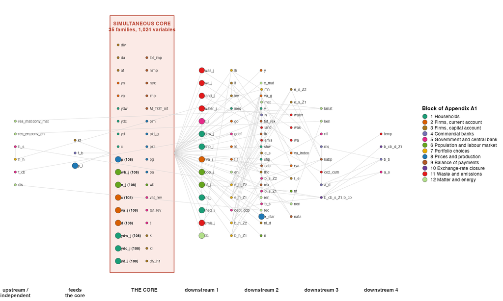

Condensation of the contemporaneous dependency graph of the reported arm. Each node is a variable family; every strongly connected component is contracted to a single node, so the graph is acyclic, and the simultaneous core is drawn opened into its member families (sectoral families with their 108 variables in bold). Colour: the block of Appendix A1 whose equation defines the family. Horizontal position: longest-path depth from the core. The ecological and distributional indicators are strictly downstream of the circular flow. Source: R/figures/plot_dependency_graph.R.

Contracting to variable blocks gives 123 blocks in 86 components, and the condensation is acyclic (checked with `igraph::is_dag()`). The core is a single node of 35 blocks. Everything to its right is reachable from it, and nothing on that side returns within the period. The layers are longest-path depth from the core: 42 blocks at depth 1, 22 blocks at depth 2, 8 blocks at depth 3, 4 blocks at depth 4. The ecological cascade runs the full width: sectoral emissions at depth 1, aggregate emissions at depth 2, cumulative CO$_2$ at depth 3 and temperature at depth 4, where it ends. 3 blocks feed the core without receiving from it: `p_t`, `kt`, `f_b`. They are the basic prices of production $\mathbf{p}_t$, the two capital targets, government investment and its depreciation, and bank profits.

### Do the indicators feed back over time?

The condensation answers the question within a period. Over time, an indicator could still feed back through a lagged read. To test this, the current-period and lagged graphs were joined, and for each of 24 indicators it was asked whether any path, of any length, leads back to the core. Only 1 indicator does: `gdef`. The government deficit adds to the bill stock, and next period’s interest on the bills enters disposable income and taxes.

None of the ecological indicators returns, and none of the distributional ones does either: emissions, cumulative CO$_2$, temperature, material extraction and recycling, land, water, waste, the material and energy stocks, the wage and profit shares, inequality and unemployment.

### What this implies for the model’s scope

In Sraffa’s terms, the basics of this model are the 1,024 variables of the circular flow. Emissions, materials, land, water, inequality and temperature are non-basic in exactly his sense: they can be deleted without disturbing the determination of anything else, in any period. Stated plainly, and without presenting it as a virtue: **emissions and material depletion do not feed back into production or prices in this model.** Ecological damage is accounted, not transmitted. That is a deliberate simplification appropriate to the question the model is asked — how a circular-economy transition redistributes material throughput and income between core and periphery. But it means the model cannot represent ecological damage constraining accumulation, and results should not be read as if it could.

## B3 The model as a dynamical system

**In the paper.** Cited from the main text (2 reference(s)). Stale passages for item 3 in the rendered text: EU/RoW 2, RoW (alone) 2.

The numerical results in this appendix come from the archived `output/scenarios/full_mrio_baseline_2026.RDS` and the September 9 transition-matrix experiment, before the current `revised` arm was built. They describe that historical configuration only. The accounting correction in `qmd/reports/2026-09-11-fiscal-and-external-accounts.qmd` also changes the interpretation of its two unstable roots. The last subsection reports the transition matrices of the model the Results use, which supersede these numbers.

The model is written as a period loop containing a fixed-point iteration, not as a stated law of motion. It nevertheless has one, and identifying it makes the model’s dynamic properties available to standard analysis.

Writing $s_t \in \mathbb{R}^{6713}$ for the full state at period $t$ and $\theta$ for the parameters, the equation block is

$$s_t = F(s_t,\, s_{t-1};\, \theta) \tag{A5.1}$$

— implicit, because $s_t$ appears on both sides, which is what the Gauss–Seidel iteration resolves. Whether the system is *first-order* is an empirical question about the source, and it was checked by counting: of the lag references in the equation block, **all 165 are exactly one period** ($t-1$), and none is deeper; 169 assignments target the current column and none targets a past one. No companion-form augmentation is therefore needed — the state vector as it stands is already the right state for a first-order system.

Linearising (A5.1) about a point on the baseline path, and writing $J_c = \partial F/\partial s_t$ for the within-period Jacobian and $J_\ell = \partial F/\partial s_{t-1}$ for the lagged one,

$$ds_t = J_c\, ds_t + J_\ell\, ds_{t-1} \quad\Longrightarrow\quad
ds_t = \underbrace{(I - J_c)^{-1} J_\ell}_{M}\, ds_{t-1}. \tag{A5.2}$$

The structure of $M$ is worth naming. $(I - J_c)^{-1}$ is a Leontief inverse — not by analogy but literally the same algebraic object as the input–output inverse $(I - \mathbf{A})^{-1}$, taken across *equations* rather than across sectors. All of the simultaneity and all of the multiplier structure live in that inverse and contribute no dynamics of their own; it is an instantaneous propagator. Everything genuinely dynamic is in $J_\ell$.

One further property makes $M$ interpretable across periods. $M$ is time-varying, because the technology matrix drifts: $A_i = (1-\phi_i)A_{i-1} + \phi_i B$, a partial adjustment toward the circular target $B$. That recursion telescopes exactly to

$$A_i = B + (A_1 - B)\prod_{s \le i}(1 - \phi_s), \tag{A5.3}$$

verified against the implemented recursion to $1.4 \times 10^{-17}$ against a target gap $\max|B - A_1| = 0.0339$, with $\phi$ constant within each purchasing region’s column block. The technology transition is thus a one-dimensional geometric mode per region: $A$ slides along the fixed ray $(A_1 - B)$ toward the target. The time-variation in $M$ that comes through technology is a scalar schedule known in advance, not an unknown drift. Two calibration facts complete the picture: the autonomous speed of adjustment is zero in both regions and government-expenditure growth is zero, so government spending is the *sole* driver of circular-economy technical change in this model, and with expenditure flat the adjustment rate is constant over the whole horizon ($\phi^{Z_1} = 0.1182$ in every period).

### The spectrum of the transition matrix

$M$ was formed explicitly as a $588\times588$ matrix by finite differences: each of the 588 lagged coordinates was perturbed alone by a relative $\varepsilon = 10^{-6}$ and one period re-solved, the solve using a *fixed* 130 Gauss–Seidel sweeps rather than the adaptive stopping rule, because the adaptive rule’s iteration count is integer-valued and makes the period map discontinuous in $s_{t-1}$. The restriction to 588 coordinates was itself verified rather than assumed: perturbing a sample of the excluded live variables moves the next period’s state by exactly zero.

$M$ was built independently at three points on the baseline path, $t = 30$, $t = 50$ and $t = 80$. All three give the same division of the spectrum into three parts:

Table 3: Distribution of the 588 eigenvalues of the one-period transition matrix.

|  | eigenvalues |
| --- | --- |
| inside the unit circle ($\lvert\lambda\rvert < 1 - 10^{-6}$), of which 217 to 327 are numerically zero | 481 |
| unit roots ($\lvert\lambda\rvert$ within $10^{-6}$ of 1) | 105 |
| outside the unit circle | 2 |

so that $\rho(M) = 1.02167305 > 1$ for the archived configuration. The two roots outside the unit circle are real; their eigenvectors load heavily on government bills and central-bank bill holdings. Numerically,

$$\lambda_1 = 1.02167305 = 1 + r_b^{Z_2}, \qquad \lambda_2 = 1.02159126 = 1 + r_b^{Z_1},$$

matching the calibrated bill rates $r_b^{Z_2} = 0.0216730467$ and $r_b^{Z_1} = 0.0215912638$ to within $4\times10^{-9}$ — the resolution of the finite difference. The subsequent accounting audit found that one root is an economic mode through the unrecycled official-sector bill circuit, while the other lies off the bill-market identity and is an accounting-residue direction. The lack of a fiscal reaction function leaves the economic circuit undamped; the two roots do not establish two independent regional debt-compounding mechanisms.

The 105 unit roots are the stock-accumulation identities — cumulative CO$_2$, the capital stocks, cumulative waste, durable consumption, central-bank holdings — each of which adds a flow to a stock with no depreciation or with depreciation netted elsewhere. Because 105 eigenvalues coincide, the individual eigenvectors within that cluster are not identified (any basis of the invariant subspace serves), so only the set of variable blocks it spans is reported and not the split between them.

$\rho(M)$ is unchanged to eight decimal places across all three base points. That is not a coincidence and it does not indicate that $M$ is time-invariant — $M$ does vary, through the technology drift of (A5.3). It follows from the leading eigenvalue being $1 + r_b$: the policy rate and its mark-up are both constant in the calibration, so the dominant root is a fixed parameter of the model rather than an outcome of it.

This spectrum is evidence about local dynamics in the archived configuration at the three measured base points. It does not establish attraction of a shocked trajectory, economic admissibility of its financial stocks, or stability of the current revised arm.

### Spectrum of the gold-closure comparator

Local spectrum of the one-period transition matrix $M$ of the North/South gold-closure comparator, unshocked baseline at $t = 100$. Sources: `data/transition/<arm>/` (`spectrum_counts_t100.csv`, `feedback_summary_t100.csv`, `complex_pairs_t100.csv`, `transition_matrix_validate.rds`).

| Quantity | North/South |
| --- | --- |
| Dimension of $M$ (lagged variables that move the next period) | 826 |
| Roots on the unit circle ($\lvert\lvert\lambda\rvert - 1\rvert \le 10^{-6}$) | 321 |
| Roots inside the unit circle (of which numerically zero) | 505 (231) |
| Roots outside the unit circle | 0 |
| Spectral radius | 1.000000001 |
| Spectral radius, states that can feed activity or settlement | 1.000000000 |
| Leading complex pair: $\lvert\lambda\rvert$ / period / half-life (periods) | 0.742 / 23.9 / 2.3 |
| Second complex pair: $\lvert\lambda\rvert$ / period | 0.004 / 2.1 |
| Validation: max $\lvert s^{fixed} - s^{stored}\rvert / \max(\lvert s^{stored}\rvert, 1)$ | 1.2e-08 |
| Validation: excluded coordinates that move the next period (of 20) | 0 |
| Build time (minutes) | 431 |

The construction is the one described above, applied to the gold-closure comparator: $M$ is formed by finite differences of the full period solve at $t = 100$, perturbing each lagged coordinate that moves the next period’s solution, with a fixed number of Gauss–Seidel sweeps so that the period map is smooth. Three results follow.

**No economic mode is unstable.** No root lies outside the unit circle. The spectral radius exceeds one by 6e-10, and restricted to the states that can feed activity or settlement by 4e-10, the resolution of the finite difference. No root lies at $1 + r_b$, where the archived configuration had its two unstable roots.

**The unit roots are stock-accumulation identities.** 321 roots lie on the unit circle: the stocks that add a flow with no depreciation. The leading ones load on net foreign liabilities, central-bank bill holdings, gold reserves, the durable-consumption stock and cumulative sectoral waste. As before, the eigenvectors inside that cluster are not identified individually.

**The baseline cycle is one complex pair.** The slowest oscillation is a pair with modulus 0.742 and period 23.9, loading on sectoral employment and output (0.75 of the eigenvector’s modulus) and on net foreign liabilities: the multiplier–accelerator mode, with a half-life of 2.3 periods. It is damped too fast to show as a cycle in the North/South baseline; in the EU/RoW setup of earlier versions, with the government accelerator on, the same mode had a half-life of about 16 periods and the baseline cycled visibly. The next pair is fast (modulus 0.004).

This is local evidence at one point of the baseline path. It does not establish that a shocked trajectory returns to its baseline; only the shocked runs themselves can show that.

### The damped cycle and the reporting window

**The damped cycle and the government accelerator.** A baseline with both accelerators on returns to rest through a damped cycle of about 22 periods: the firms’ (3.2), and the government’s, which closes the gap to a target public capital stock at speed $\gamma_g$. In North/South $\gamma_g = 0$, so public investment replaces depreciation and the cycle is damped away. The North/South fiat baseline turns 1 time(s) over $t = 10\ldots100$; with $\gamma_g = 0.15$ it would turn 8 times (`R/dynamics/gamma_g_cycle.R`). Lowering the firms’ speed of adjustment from 0.15 to 0.05 also removes the oscillation. This is the multiplier–accelerator interaction of Samuelson (1939). In the spectrum of the North/South gold comparator the cycle is one complex pair, loading on sectoral output and employment, the variables the capital target reads, and on net foreign liabilities: period 23.9, $|\lambda|$ = 0.742, a half-life of 2.3 periods. The mode is present, but damped too fast to show as a cycle.

**The reporting window.** Because a baseline with both accelerators on ($\gamma_g > 0$, as in the EU/RoW setup of earlier versions) is still cycling when the interventions start at $t = 70$, a response read at a single date would depend on the phase of the cycle at that date. Every response in this paper is therefore the mean over $t = 79\ldots100$, one full cycle, of the run’s deviation from its own unshocked baseline, and the cross-border classification is applied to that mean. It is a medium-run comparison, not a steady-state effect; Section 5 reports the drift after $t = 100$.

## C1 Sector list

**In the paper.** Cited from the main text (1 reference(s)). No EU/RoW, RoW, OPENFIXG or 96-run passage.

The model comprises 54 sectors per region (108 total across North and South). Each region shares an identical sector structure. Ten named material categories are represented, but only nine have a primary/secondary substitution pair. Paper (sector 15) has no Paper Re-processing sector: Pulp Re-processing (sector 14) uses secondary paper to make pulp and is the secondary member of the pulp pair. The twelve presentation interventions use eight pairs; construction is outside the matched comparison grid. Secondary/reprocessing sectors involved in circular economy substitutions are marked with $\star$.

Sector List. CE substitution pairs by intervention and demand channel. F = final demand, I = intermediate demand; Cons. = household consumption, Gov. = government consumption, Prod. = firms' intermediate inputs. Primary = source sector; Secondary = reprocessing sector. Regime: the cross-border regime of each intervention, in the order of the Scenario column, with no fiscal rule (North/South, OPENFIX-fiat): PL production leakage, CD competitive displacement, CE contained expansion, CC contained contraction, DC dual contraction. Construction is outside the twelve interventions.

| \# | Sector | Role | Scenario | Channel | Demand | Regime, no rule |
| --- | --- | --- | --- | --- | --- | --- |
| 1 | Agriculture |  |  |  |  |  |
| 2 | Animal Farming |  |  |  |  |  |
| 3 | Forestry, Logging |  |  |  |  |  |
| 4 | Fishing |  |  |  |  |  |
| 5 | Fossil-Fuel Extraction |  |  |  |  |  |
| 6 | Mining |  |  |  |  |  |
| 7 | Meat | Primary | sc1, sc12 | Cons., Prod. | F, I | PL, PL |
| 8 | Other Food | Secondary | sc1, sc12 | Cons., Prod. | F, I | PL, PL |
| 9 | Tobacco |  |  |  |  |  |
| 10 | Textiles |  |  |  |  |  |
| 11 | Wood | Primary | sc3, sc5 | Cons., Prod. | F, I | CE, PL |
| 12 | Wood Re-processing | Secondary | sc3, sc5 | Cons., Prod. | F, I | CE, PL |
| 13 | Pulp | Primary | sc6 | Prod. | I | CC |
| 14 | Pulp Re-processing | Secondary | sc6 | Prod. | I | CC |
| 15 | Paper |  |  |  |  |  |
| 16 | Fossil-Fuel Processing |  |  |  |  |  |
| 17 | Plastics | Primary | sc4, sc7 | Gov., Prod. | F, I | DC, CC |
| 18 | Plastics Re-processing | Secondary | sc4, sc7 | Gov., Prod. | F, I | DC, CC |
| 19 | Chemicals |  |  |  |  |  |
| 20 | Rubber, Plastic Products |  |  |  |  |  |
| 21 | Glass | Primary | sc9 | Prod. | I | CC |
| 22 | Glass Re-processing | Secondary | sc9 | Prod. | I | CC |
| 23 | Other Non-metallic Mineral Products |  |  |  |  |  |
| 24 | Cement | Primary | sc10 | Prod. | I | CE |
| 25 | Clinker Re-processing | Secondary | sc10 | Prod. | I | CE |
| 26 | Metals | Primary | sc8 | Prod. | I | CD |
| 27 | Metals Re-processing | Secondary | sc8 | Prod. | I | CD |
| 28 | Durable Goods |  |  |  |  |  |
| 29 | Furniture |  |  |  |  |  |
| 30 | Recycling |  |  |  |  |  |
| 31 | Fossil-Fuel Electricity | Primary | sc2, sc11 | Cons., Prod. | F, I | CD, CD |
| 32 | Renewable Electricity | Secondary | sc2, sc11 | Cons., Prod. | F, I | CD, CD |
| 33 | Energy Transmission, Distribution |  |  |  |  |  |
| 34 | Gas |  |  |  |  |  |
| 35 | Water |  |  |  |  |  |
| 36 | Construction | Primary | none |  |  |  |
| 37 | Construction Re-processing | Secondary | none |  |  |  |
| 38 | Vehicle Sale, Maintenance, Repair |  |  |  |  |  |
| 39 | Vehicle Fuel Sale |  |  |  |  |  |
| 40 | Retail, Wholesale Trade |  |  |  |  |  |
| 41 | Leisure |  |  |  |  |  |
| 42 | Transport |  |  |  |  |  |
| 43 | Professional Services |  |  |  |  |  |
| 44 | Real Estate |  |  |  |  |  |
| 45 | Machine, Equipment Renting |  |  |  |  |  |
| 46 | R\&D |  |  |  |  |  |
| 47 | Public Administration, Defence |  |  |  |  |  |
| 48 | Education |  |  |  |  |  |
| 49 | Health, Social Work |  |  |  |  |  |
| 50 | Waste Incineration |  |  |  |  |  |
| 51 | Biogas, Composting |  |  |  |  |  |
| 52 | Waste Water |  |  |  |  |  |
| 53 | Waste Landfill |  |  |  |  |  |
| 54 | Other Services |  |  |  |  |  |

### From EXIOBASE industries to the 54 sectors, and the primary/secondary pairs

The 54 sectors are aggregates of the 163 EXIOBASE 3 industries, given by the concordance `data/exiobase/exiobase_sector_concordance.csv`. Write $C$ for the $54 \times 163$ concordance matrix, $c_{Ji} = 1$ when EXIOBASE industry $i$ belongs to model sector $J$ and 0 otherwise, and $C_R = I_2 \otimes C$ for its two-region form (the 49 EXIOBASE regions are first summed into two by the region concordance in the same way). From the EXIOBASE flow matrix $Z^E$, final-demand matrix $Y^E$, gross output $\mathbf{x}^E$ and satellite rows $E^E$:

$$\mathbf{x} = C_R\,\mathbf{x}^E, \qquad Z = C_R Z^E C_R^{\top}, \qquad A = Z\,\hat{\mathbf{x}}^{-1},
\qquad Y = C_R Y^E, \qquad \mu_J = \frac{\sum_{i \in J} (\mathrm{DEU}_i + \mathrm{UDE}_i)}{x_J}.$$

Every intensity is formed the same way, as the sector’s summed satellite row over its summed output; no material category is weighted. The columns of $Y$ are the EXIOBASE final-demand categories, summed into the model’s household, government and investment channels (`tools/exiobase/exio_mrio_aggregate.py`). Every pair is an aggregation of this kind; none is built by splitting an EXIOBASE industry or by imputation.

Seven of the nine pairs are read off the EXIOBASE classification itself. EXIOBASE 3 separates the primary production of a material from the re-processing of its secondary form, as industries whose codes end in `.w`, and the secondary sector of each of these seven pairs consists of those industries only. The food and energy pairs are groupings chosen for the paper. Food moves demand from meat, dairy, fish and vegetable-oil processing to the other food and beverage industries (rice, sugar, food n.e.c., beverages): both sides are food-*processing* industries, not agriculture. Energy groups non-renewable electricity generation (coal, gas, nuclear, oil) against renewable generation; EXIOBASE’s residual “electricity nec” falls on the renewable side.

The nine primary/secondary pairs: model sector and the EXIOBASE 3 industry codes it aggregates. Source: EXIOBASE re-processing = the secondary sector is EXIOBASE’s own re-processing industry (codes ending .w); grouping = both sides are groups of EXIOBASE industries chosen for the paper. Paper (sector 15: `i21.2`, `i22`) has no secondary partner. Construction is outside the presentation grid. Built from `data/exiobase/exiobase_sector_concordance.csv`; also written by `R/data_build/concordance_units_upstream.R` to `output/review/r2_8_10_20261015/pairs.csv`.

| Material | Primary | Secondary | Source |
| --- | --- | --- | --- |
| Food | 7 Meat: `i15.a`, `i15.b`, `i15.c`, `i15.d`, `i15.e`, `i15.f`, `i15.k` | 8 Other Food: `i15.g`, `i15.h`, `i15.i`, `i15.j` | grouping |
| Energy | 31 Fossil-Fuel Electricity: `i40.11.a`, `i40.11.b`, `i40.11.c`, `i40.11.f` | 32 Renewable Electricity: `i40.11.d`, `i40.11.e`, `i40.11.g`, `i40.11.h`, `i40.11.i`, `i40.11.j`, `i40.11.k`, `i40.11.l` | grouping |
| Wood | 11 Wood: `i20` | 12 Wood Re-processing: `i20.w` | EXIOBASE re-processing |
| Pulp | 13 Pulp: `i21.1` | 14 Pulp Re-processing: `i21.w.1` | EXIOBASE re-processing |
| Plastics | 17 Plastics: `i24.a` | 18 Plastics Re-processing: `i24.a.w` | EXIOBASE re-processing |
| Glass | 21 Glass: `i26.a` | 22 Glass Re-processing: `i26.a.w` | EXIOBASE re-processing |
| Cement | 24 Cement: `i26.d` | 25 Clinker Re-processing: `i26.d.w` | EXIOBASE re-processing |
| Metals | 26 Metals: `i27.41`, `i27.42`, `i27.43`, `i27.44`, `i27.45`, `i27.5`, `i27.a` | 27 Metals Re-processing: `i27.41.w`, `i27.42.w`, `i27.43.w`, `i27.44.w`, `i27.45.w`, `i27.a.w` | EXIOBASE re-processing |
| Construction | 36 Construction: `i45` | 37 Construction Re-processing: `i45.w` | EXIOBASE re-processing |

**Units.** Every monetary quantity in the workbook is EXIOBASE 2011 million euros divided by $10^4$, so one model unit is EUR 10 bn (`tools/workbooks/build_aggregation_workbook.py`). Output, final demand and the real expenditure aggregates are volumes at 2011 basic prices. Stocks and income flows are nominal, in the same unit at current prices. Material throughput $x_{mat} = \sum_j \mu_j x_j$ and the derived material flows are physical, in units of 10 Mt: $\mu_j$ is in kt per million euros, which is 10 Mt per model unit. Energy flows are in EJ.

The model’s output is not EXIOBASE’s divided by exactly $10^4$, because $\mathbf{x}$ is the model’s own solution after the spin-up. At $t = 70$ of the reported North/South fiat baseline, EXIOBASE 2011 gross output per unit of $\mathbf{x}$ has a median of 10,713 million euros over the North’s 54 sectors and 11,502 over the South’s. For the eighteen sectors of the nine pairs it lies between 7,653 (Construction) and 11,473 (Metals) in the North. The comparison uses EXIOBASE aggregated with the workbook’s own North/South region concordance (`data/exiobase/impacts/mrio_2011_North_South_x.csv`). The North’s material throughput in the model, 3,229 (32.3 Gt), is 84.8% of the value EXIOBASE’s 2011 output vector gives with the same intensities, 3,807 (38.1 Gt); for the South the two are 7,192 and 8,811 (81.6%). The model’s throughput is lower than its output because the model produces less than the data in the most material-intensive sectors: Fossil-Fuel Extraction has the largest ratio in the North (13,041) and Durable Goods in the South. Output files: `units.csv` and `units_pair_sectors.csv` in `output/review/r2_8_10_20261126_ns/` (`SETUP=ns Rscript R/data_build/concordance_units_upstream.R`).

## C2 Country list

**In the paper.** Cited from the main text (1 reference(s)). No EU/RoW, RoW, OPENFIXG or 96-run passage.

The two regions are aggregates of the 44 countries and five rest-of-world blocks of EXIOBASE 3.8.2. The Global North is the EU-27 of 2011 except Croatia, with the other high-income economies; the Global South is the large middle-income economies, Croatia and the five rest-of-world blocks.

Country list: the EXIOBASE 3.8.2 regions of each model region. Source: `data/exiobase/exiobase_region_concordance_North_South.csv`.

[output not shown]

## C3 List of supplementary tables and figures

**Candidate.** In the supplement, not cited from the main text: cite it or move it out. No EU/RoW, RoW, OPENFIXG or 96-run passage.

The tables and figures of the paper itself are listed in the paper. Where a source is described rather than named, its full path is given on the accompanying evidence site.

[output not shown]

## D1 Cluster structure of the 48 runs

**In the paper.** Cited from the main text (1 reference(s)). Stale passages for item 3 in the rendered text: 96 runs 1.

The clustering describes the signed responses of the 48 runs of the paper’s Results: North/South, OPENFIX-fiat, the North’s money as the reserve asset, the North making each of the twelve interventions under each of the four fiscal rules (no rule, the South adjusts, the North adjusts, both adjust). The paper does not derive its regime labels from it; they come from an explicit sign rule on the two regions’ value added (Section 5 of the paper).

**Data and method.** Each run is described by its 74 responses (the variables of both regions, each a mean over $t = 79\ldots100$ against the run’s own unshocked baseline). Each response is standardised across the 48 runs, and each of the six blocks (ecological 16, external 8, finance and wealth 10, fiscal 10, labour and distribution 18, real activity 12 responses) is given equal weight by dividing its columns by the square root of the block size. Runs are joined by Ward’s criterion on Euclidean distances: at each step the two groups whose union adds least to the within-group sum of squares are merged. The quality of a cut into $k$ groups is read from the mean silhouette width, which compares each run’s distance to its own group with its distance to the nearest other group, on a scale from −1 to 1 on which values above 0.5 indicate reasonable structure.

Mean silhouette width of the Ward tree of the 48 runs, by number of groups. Source: recomputed from `output/calibration/transmission_clusters_20261121_ce79/responses_emis_a2_lw.csv`; the same values are in `results48_numbers.json`.

| Groups k | Mean silhouette |
| --- | --- |
| 2 | 0.486 |
| 3 | 0.505 |
| 4 | 0.454 |
| 5 | 0.464 |
| 6 | 0.476 |
| 7 | 0.477 |
| 8 | 0.488 |
| 9 | 0.487 |

The mean silhouette is highest at $k = 3$ (0.505), the only cut above 0.5: food, metal and the rest. The cut at $k = 4$ (0.454) separates energy, and is the finest at which the four runs of every intervention stay in one group. The cuts that follow separate runs of the same intervention by fiscal rule: sc1 HH-Food at $k$ = 5, sc12 Int-Food at 6 and sc8 Int-Metal at 7. Industrial wood (sc5 Int-Wood) leaves the rest at $k = 9$.

The paper’s figure therefore does not use a single cut. It reads five families from the nesting of the tree: food (separate from $k = 2$), metal ($k = 3$), energy ($k = 4$), industrial wood ($k = 9$) and the low-response core that remains. Each family is a whole branch of the tree and holds all four runs of each of its interventions, so the fiscal rule never moves an intervention from one family to another. The mean silhouette of this five-family partition is 0.442: it describes the tree, and is not offered as a better cut than $k = 3$.

The five families, their regimes and the responses that most distinguish them are in the paper’s table of the Ward families (Section 5).

The families group interventions, not fiscal rules or regimes. Against the fiscal rule the five-family partition has an adjusted Rand index of -0.06, which is no association (the index is 0 for a random partition and 1 for identical ones). Against the sign-rule regimes it is 0.24: the food family is mostly production leakage and the energy and metal families mostly competitive displacement, but the low-response core holds runs of several regimes, and the regime of an intervention can change with the rule while its family does not.

*Principal components and the fiscal rules.* In the principal components of the 48 runs, the first component (48.8% of the variation) is the North’s external position, with food at one end and metal and energy at the other; the second (22.2%) is Southern activity; the third (11.8%) is the balance between the regions, on which the two current accounts and trade balances load with opposite signs. The rules move runs along this third axis: the first common direction of the 36 moves from no rule carries 71.6% of their squared length, and its absolute cosine with the third component is 0.89.

The clusterings of the previous versions, over the fourteen submitted scenarios and over the 96-run grid of two regional setups and four closures, are superseded by this one.

## D2 Scenario highlights

**In the paper.** Cited from the main text (1 reference(s)). No EU/RoW, RoW, OPENFIXG or 96-run passage.

One row per intervention, over the 48 runs of the Results (North/South, OPENFIX-fiat, the North’s money; each intervention under no rule and the three fiscal rules). On each of four axes the table names the response on which the intervention stands out most: among that axis’s variables in the North, the South and, for emissions and extraction, the world, the one with the largest ratio of the intervention’s mean absolute response to the mean absolute response of all 48 runs. The value is the mean over the intervention’s four runs; the rank compares the twelve interventions on that response. The last column gives the fiscal rule with the highest world value added and its gain over no rule, and how many of the three rule runs change the intervention’s regime.

Scenario highlights of the twelve interventions, 48 runs (regime with no fiscal rule in brackets: PL production leakage, CD competitive displacement, CE contained expansion, CC contained contraction, DC dual contraction). Responses: mean over $t = 79..100$ against the run’s own baseline, mean over the four fiscal rules; % for levels, pp for shares and debt/GDP, % of baseline value added for the current account and trade balance. Source: `R/scenarios/highlights_48.R`.

| Intervention | Economic | Social | Ecological | External | Policy |
| --- | --- | --- | --- | --- | --- |
| sc1 HH-Food (PL) | South public debt/GDP falls (-0.198 pp, largest of 12) | South worker-capitalist income gap rises (+0.119 pp, largest of 12) | South water use rises (+0.246 %, largest of 12) | South current account rises (+0.0036 % of VA, largest of 12) | South adjusts (+0.095 pp of world VA); regime changes in 1 of 3 rule runs |
| sc2 HH-Energy (CD) | North real investment rises (+0.141 %, 3rd largest of 12) | North employment rises (+0.019 %, 5th largest of 12) | World CO$_2$ emissions falls (-0.644 %, 2nd largest of 12) | North real imports rises (+0.026 %, 5th largest of 12) | North adjusts (+0.013 pp of world VA); regime changes in 0 of 3 rule runs |
| sc3 HH-Wood (CE) | North real consumption rises (+0.0032 %, 10th largest of 12) | South wage share falls (-0.0006 pp, 10th largest of 12) | South land use falls (-0.018 %, 5th largest of 12) | North real imports rises (+0.0028 %, 8th largest of 12) | North adjusts (+0.0012 pp of world VA); regime changes in 0 of 3 rule runs |
| sc4 Gov-Plastics (DC) | North real consumption falls (-0.0095 %, 5th largest of 12) | South wage share falls (-0.0016 pp, 7th largest of 12) | South CO$_2$ emissions falls (-0.014 %, 7th largest of 12) | South trade balance falls (-0.0001 % of VA, 7th largest of 12) | North adjusts (+0.0073 pp of world VA); regime changes in 1 of 3 rule runs |
| sc5 Int-Wood (PL) | South real investment rises (+0.059 %, 4th largest of 12) | North worker-capitalist income gap rises (+0.172 pp, largest of 12) | North land use falls (-4.24 %, largest of 12) | South real imports rises (+0.035 %, 4th largest of 12) | South adjusts (+0.0039 pp of world VA); regime changes in 1 of 3 rule runs |
| sc6 Int-Pulp (CC) | North real consumption rises (+0.0026 %, 11th largest of 12) | North wage share rises (+0.0016 pp, 10th largest of 12) | South land use falls (-0.011 %, 6th largest of 12) | South real imports rises (+0.0026 %, 10th largest of 12) | no rule; regime changes in 0 of 3 rule runs |
| sc7 Int-Plastics (CC) | North value added falls (-0.011 %, 7th largest of 12) | North wage share rises (+0.0086 pp, 6th largest of 12) | South material extraction falls (-0.026 %, 6th largest of 12) | South real imports rises (+0.012 %, 7th largest of 12) | South adjusts (+0.0007 pp of world VA); regime changes in 2 of 3 rule runs |
| sc8 Int-Metal (CD) | North real consumption rises (+0.081 %, largest of 12) | North employment rises (+0.101 %, largest of 12) | South material extraction falls (-0.561 %, largest of 12) | South current account falls (-0.0034 % of VA, 2nd largest of 12) | North adjusts (+0.069 pp of world VA); regime changes in 1 of 3 rule runs |
| sc9 Int-Glass (CC) | North real consumption rises (+0.0037 %, 8th largest of 12) | North wage share rises (+0.0037 pp, 8th largest of 12) | North material extraction falls (-0.085 %, 9th largest of 12) | North current account rises (+0.0001 % of VA, 8th largest of 12) | North adjusts (+0.0020 pp of world VA); regime changes in 2 of 3 rule runs |
| sc10 Int-Cement (CE) | North value added rises (+0.0086 %, 8th largest of 12) | North capitalists’ income rises (+0.015 %, 8th largest of 12) | North material extraction falls (-0.223 %, 5th largest of 12) | North trade balance falls (-0.0001 % of VA, 9th largest of 12) | North adjusts (+0.0034 pp of world VA); regime changes in 1 of 3 rule runs |
| sc11 Int-Energy (CD) | North real investment rises (+0.287 %, largest of 12) | North capitalists’ income rises (+0.128 %, 3rd largest of 12) | World CO$_2$ emissions falls (-1.26 %, largest of 12) | North real imports rises (+0.079 %, 2nd largest of 12) | South adjusts (+0.0096 pp of world VA); regime changes in 3 of 3 rule runs |
| sc12 Int-Food (PL) | South real consumption rises (+0.044 %, 3rd largest of 12) | South worker-capitalist income gap rises (+0.079 pp, 2nd largest of 12) | North water use rises (+0.455 %, 2nd largest of 12) | South real imports rises (+0.071 %, 2nd largest of 12) | South adjusts (+0.044 pp of world VA); regime changes in 1 of 3 rule runs |

## B8 The fiscal programme under OPENFIXG (removed)

**Not in the paper.** Removed from the supplement on 2026-11-26 (ff7aae26): the OPENFIXG fiscal programme of the earlier 96-run grid. The 48 runs use OPENFIX-fiat with a proportional fiscal rule (fiscal_spec = symmetric). Shown as last rendered, at 0dbbcb68.

Under OPENFIXG no reserves move, and the government of the reserve-holding region adjusts: the EU (the intervening region) in EU/RoW and the South (the partner) in North/South. The table counts, by cross-border regime and regional setup, the interventions in which that government’s real spending contracts or expands, and gives how much its response amplifies or dampens the partner’s value-added response relative to gold.

Fiscal programme of the adjusting government under OPENFIXG, by cross-border regime and regional setup: number of interventions in which its real spending contracts or expands, and the median ratio of the partner's absolute value-added response under OPENFIXG to its response under gold (above 1: amplified; below 1: dampened). The adjusting government is that of the reserve-holding region: the EU (the intervening region) in EU/RoW, the South (the partner) in North/South. Means over t = 79..100 against each calibration's own baseline.

| OPENFIXG regime | EU/RoW: EU adjusts Contraction | EU/RoW: EU adjusts Expansion | EU/RoW: EU adjusts Partner ratio | North/South: South adjusts Contraction | North/South: South adjusts Expansion | North/South: South adjusts Partner ratio |
| --- | --- | --- | --- | --- | --- | --- |
| Contained contraction | 7 | 3 | 0.10 | 2 | 1 | 1.78 |
| Production leakage | 1 | 0 | 0.21 | 0 | 2 | 4.28 |
| Competitive displacement | 0 | 1 | 0.14 | 3 | 0 | 2.55 |
| Dual contraction | 0 | 0 |  | 3 | 0 | 3.77 |
| Dual expansion | 0 | 0 |  | 0 | 1 | 5.24 |
| All twelve | 8 | 4 | 0.10 | 8 | 4 | 3.74 |

## A2 Alternative exchange-rate closures (removed)

**Not in the paper.** Removed on 2026-11-26 in the restructure into Parts A-D: the alternative exchange-rate closures (gold, OPENFIXG, quasi-float). The paper uses OPENFIX-fiat and its reversed hierarchy, both now in Block 10 of A1, which also keeps one paragraph on gold settlement for the paper's footnote. Shown as last rendered, at a771c74c.

An external closure specifies which variable absorbs an imbalance between the two areas: the stock of official reserves, government spending or the exchange rate. The production, price, income and portfolio equations (Blocks 0 to 9 and 11 to 13 of Appendix A1) are shared by all closures. Comparing closures therefore shows how settlement institutions modify the response of the two economies to the same circular-economy intervention.

Each alternative closure is defined by the equations it replaces in Block 10 (and, in one case, in Block 5), while every other equation is unchanged. Equations are numbered after the equation they replace, followed by a letter that identifies the closure: for instance, (10.7A) replaces equation (10.7) under closure A. In every case, the initial run of Block 0 is solved under the gold-settlement closure (A), and the selected closure applies from period 1 onwards. Each closure is calibrated and assessed against its own unshocked baseline.

Where settlement involves interest-bearing foreign bills, the model embodies an explicit monetary hierarchy: the central bank of one area holds the bills of the other area as reserves, whereas the reverse does not happen. Throughout, $z$ denotes the reserve-holding area and $f$ the area whose bills serve as reserves. The reserve-holding area is the European Union in the EU/RoW setup and the South in the North/South setup, so that the North/South equations are obtained by swapping the area indices. This assignment is a choice of closure, not a property of the regions. Under closures A and C, the foreign-bill holdings of both central banks are frozen, and gold settles the balance of payments, so that no area’s money plays the role of world money and the closure is neutral between the two areas. The table below summarises the four implemented closures.

The four implemented external closures.

| **Closure** | **Exchange rate** | **What absorbs the external imbalance** |
| --- | --- | --- |
| R. OPENFIX-fiat | Fixed | Foreign bills held by the central bank of the reserve-holding area |
| A. OPENFIX-gold | Fixed | Gold stocks of both central banks |
| B. OPENFIXG | Fixed | Government spending of the reserve-holding area |
| C. Quasi-float | Crawling, lagged | Exchange rate and, residually, gold |

Two equations are common to all closures: the exchange rate of the other area is the reciprocal of the domestic one, and the change in the exchange rate is defined as usual:

$$xr^f = \frac{1}{xr^z} \tag{10.1}$$

$$\Delta xr^z\;\;(\texttt{dxr}) = xr^z - xr_{-1}^z \tag{10.1a}$$

When the exchange rate is not fixed (closure C), the capital gains on foreign assets in disposable income (1.2) and in the realised returns of the portfolio block (7.0) are no longer nil.

### R. Fixed Exchange Rate with Fiat Reserves (OPENFIX-fiat)

This is the reference closure presented in Block 10 of Appendix A1, and it is recalled here for comparison. Following Godley and Lavoie (2007, sec. 12.4), interest-bearing bills of the other area replace gold as the moving reserve asset, which makes the monetary hierarchy and the associated interest-income circuit explicit. The exchange rate and the gold stocks are fixed, and the central bank of the reserve-holding area absorbs the residual supply of the other area’s bills:

$$xr^{z} = xr_{- 1}^{z} \tag{10.0}$$

$$B_{cb,z}^z = B_{cb,z,-1}^z + \Delta H_s^z - \Delta A_s^z - xr^f\,\Delta B_{cb,s,z}^f \tag{10.2}$$

$$B_{cb,f}^f = B_{cb,f,-1}^f + \Delta H_s^f - \Delta A_s^f \tag{10.3}$$

$$B_{s,z}^f = xr^z \cdot B_{h,z}^f \tag{10.4}$$

$$B_{cb,s,z}^f = B_s^f - B_{s,z}^f - B_{s,f}^f - B_{cb,f}^f - B_b^f \tag{10.5}$$

$$OR^z = OR_{-1}^z \tag{10.7}$$

$$OR^f = OR_{-1}^f \tag{10.8}$$

where $OR^{z}$ is the stock of gold held by the central bank of area $z$. The redundant equation is the horizontal constraint on the market for the bills of the reserve-holding area:

$$B_{cb,z}^z = B_s^z - B_{s,z}^z - B_{s,f}^z - B_b^z \tag{10.6}$$

Since reserves earn the interest rate of the issuing area, which accrues to the reserve-holding area as central-bank profit (5.9), a current account surplus increases reserves and their interest income, which further increases the surplus. Reserves therefore follow a recurrence of the form $B_{cb,s,z,t + 1}^{f} = \left( 1 + r_{b,t}^{f} \right) \cdot B_{cb,s,z,t}^{f} + \Phi_{t}$, where $\Phi_{t}$ is the non-interest component of the current account, expressed in foreign currency, and nothing in the model reacts to the stock of reserves. The baseline is therefore calibrated to a nil current account, so that reserves remain close to zero and the ratios of public debt to value added remain on target. This is a calibrated reference point rather than a general stability result: a shock that opens a current account imbalance may restart the compounding of reserves, so that a stationary baseline does not by itself establish a new stationary equilibrium after the shock.

### A. Fixed Exchange Rate with Gold Settlement (OPENFIX-gold)

*Motivation*. Gold settlement provides the canonical fixed exchange rate reference (Godley and Lavoie, 2007, sec. 12.4) without allowing interest-bearing foreign reserves to create the compounding interest circuit described above. Gold earns no interest, so that the interest paid on each government’s bills remains within its own area. The settlement convention can therefore be compared with an explicitly hierarchical fiat-reserve system.

*Equations*. The exchange rate is fixed (10.0), and the supply of foreign bills to domestic households is unchanged (10.4). Each central bank is the residual holder of its own government’s bills:

$$B_{cb,z}^z - B_{cb,z,-1}^z,\qquad B_{cb,z}^z = B_s^z - B_{s,z}^z - B_{s,f}^z - B_b^z \tag{10.2A}$$

$$B_{cb,f}^f = B_s^f - B_{s,f}^f - B_{s,z}^f - B_b^f - B_{cb,s,z}^f \tag{10.3A}$$

while the stock of foreign bills held by the central bank of the reserve-holding area is frozen (it is nil in the base-year data):

$$B_{cb,s,z}^f = B_{cb,s,z,-1}^f \tag{10.5A}$$

The balance of payments settles in gold. Each central bank’s stock of gold is the residual of its balance sheet:

$$B_s^z - B_{s,z}^z - B_{s,f}^z - B_b^z\qquad(\text{assigned by 10.2; the redundant check is } \textstyle\sum_z p_{or}^z\,\Delta OR^z = 0) \tag{10.6A}$$

*Adjustment*. Gold stocks absorb the settlement flows, and their reallocation closes the external accounts, while production, income and fiscal balances respond through the rest of the model. Since nothing reacts to the stock of gold, changes in public debt and in reserve levels may persist after real activity has settled. Calibrating the baseline is a reference condition: it does not imply that stocks return to their original levels after a disturbance.

### B. Fixed Reserves and Fiscal Adjustment (OPENFIXG)

*Motivation*. This closure asks how a fixed exchange rate regime adjusts when the reserve-holding area cannot absorb external imbalances by changing its stock of reserves. It makes the fiscal cost of the settlement constraint explicit. Following Godley and Lavoie’s OPENFIXG model (2007, chap. 12), the fiscal stance of the area that sits lower in the monetary hierarchy is made to target its external balance.

*Equations*. The exchange rate, the reserve stocks and the bill rates are fixed. The central bank of the reserve-holding area cannot buy bills beyond what its issue of money requires, so that its holding of its own government’s bills follows its balance sheet, and its gold stock is frozen:

$$B_{cb,z}^z = B_{cb,z,-1}^z + \Delta H_s^z - \Delta A_s^z \tag{10.2B}$$

$$OR^z = OR_{-1}^z \tag{10.7B}$$

The supply of bills of the reserve-holding area is whatever households, banks, the other area and the central bank demand at the fixed interest rate. The government deficit is the change in that stock, and real government spending becomes the residual of the budget constraint, replacing the exogenous rule (5.1):

$$B_s^z\;\;(\texttt{b\_s}) = B_{s,z}^z + B_{s,f}^z + B_b^z + B_{cb,z}^z \tag{5.6aB}$$

$$DEF_g^z\;\;(\texttt{gdef}) = B_s^z - B_{s,-1}^z \tag{5.5B}$$

$$gov^z\;\;(\texttt{g}) = \big(DEF_g^z - r_{b,-1}^z B_{s,-1}^z + F_{cb}^z + T^z + VAT^z + TAR^z - i_{d,g}^z p_{I,g}^z\big) / p_G^z \tag{5.1B}$$

The other area keeps its exogenous spending rule (5.1), and the remaining equations of Block 10 are those of closure A, namely (10.3A), (10.5A) and (10.8A). Since the gold stock of the reserve-holding area is frozen, the redundant equation states that the gold stock of the other area does not change either:

$$\Delta OR^f = 0 \tag{10.6B}$$

*Adjustment*. The government of the reserve-holding area can borrow only what wealth holders choose to absorb. A current account deficit drains private income and wealth, lowers the demand for bills, reduces the admissible deficit and therefore cuts government spending; a surplus works the other way round. This is the twin-deficits logic of Godley and Lavoie’s OPENFIXG model. It is not a debt-reduction rule, and it implies austerity only when the external position worsens. A symmetric assignment of reserves has no adjusting area and is therefore not an admissible setting for this closure.

### C. Crawling Exchange Rate with Gold Settlement (Quasi-Float)

*Motivation*. The quasi-float allows external prices to adjust gradually, while retaining a separate channel for the settlement of reserves. Its lagged rule avoids making the exchange rate a variable that clears the bill market within the period.

*Equations*. The exchange rate of the first area crawls with its lagged current account, expressed as a share of net income, replacing the fixed rate (10.0):

$$xr^z = xr_{-1}^z + par_{xr}\, \frac{CAB_{-1}^z}{YN_{-1}^z} \tag{10.0C}$$

where $\chi_{xr} > 0$ is the speed of the crawl, and $z$ denotes the first area ($Z1$), since the closure is neutral between the two areas. The reciprocal rate is given by (10.1), and gold settles the remaining imbalance, as in closure A: equations (10.2A), (10.3A), (10.5A), (10.7A), (10.8A) and the redundant equation (10.6A) apply.

*Adjustment*. A current account surplus of the first area raises its exchange rate in the following period. The change in buyer prices alters the Armington substitution between origins and, hence, trade flows, while gold settles the residual imbalance. The substitution between origins of intermediate inputs (13.3) is therefore essential: without it, an appreciation raises the trade balance of the appreciating area, and the exchange rate diverges. All the terms of the rule are lagged, so that there is no simultaneous loop. However, this is a numerical property rather than a proof of dynamic stability after a disturbance.

## A3 Dynamics and calibration (removed)

**Not in the paper.** Merged on 2026-11-26: its calibration detail repeated B1 (then B2) and its dynamics summary repeated B2 and B3 (then B3 and B4); the damped cycle and the reporting window moved to B3. Shown as last rendered, at a771c74c.

The following analysis and calibration details support the concise Model Features and Calibration sections of the paper. The dependency graph and baseline read-outs use the fiat reference; the transition spectrum discussed below remains an explicitly labelled gold-closure comparator.

### Dynamical analysis of the fiat reference

The model is a system of 6,747 difference equations, one per state row, of which 2,976 move during a run. Every lag is exactly one period, so it is a first-order system, $\mathbf s_t = F(\mathbf s_t, \mathbf s_{t-1})$, implicit in $\mathbf s_t$ because the period is solved by Gauss–Seidel iteration. Two questions organise its structure.

**Which equations are simultaneous: the dependency graph and its core.** Write an edge $j \to i$ when equation $i$ reads the current value of $j$. Of the graph’s 1,949 strongly connected components (maximal sets of variables each reaching every other), 1,944 are single equations evaluated in sequence; one has 1,024 variables, the **simultaneous core**, identical in both setups. It contains, for each region, the 54-sector vectors of final demand, output, prices, employment, value added and incomes, with consumption, investment, replacement, the capital stock, imports and tax revenues: the circular flow of the surplus approach, written as the Keynesian multiplier through the input–output system. This is the graph-theoretic form of Sraffa’s distinction between basic and non-basic commodities. Joining the lagged reads shows that no ecological or distributional indicator returns to the core in any number of periods (Supplementary Appendix B3): **emissions, extraction, land, water and the income shares are non-basic; ecological damage is accounted, not transmitted.**

**How the system moves between periods: linearisation.** Linearising about the baseline path, $d\mathbf s_t = J_c\,d\mathbf s_t + J_\ell\,d\mathbf s_{t-1}$, so $d\mathbf s_t = M\,d\mathbf s_{t-1}$ with $M = (I - J_c)^{-1}J_\ell$: a within-period multiplier, a Leontief inverse across equations, times the lagged reads, whose 1,076 non-zero columns carry all the dynamics. $M$ is computed by finite differences of the full period solve (Supplementary Appendix B4). A complex pair of its eigenvalues is a damped oscillation with period $2\pi/\arg\lambda$ and damping $|\lambda|$ per period, and a unit root a stock that accumulates a flow.

The full transition spectrum was calculated for the gold-closure comparator. It has not been calculated for the fiat reference.

**The damped cycle and the government accelerator.** A baseline with both accelerators on returns to rest through a damped cycle of about 22 periods: the firms’ (3.2), and the government’s, which closes the gap to a target public capital stock at speed $\gamma_g$. In North/South $\gamma_g = 0$, so public investment replaces depreciation and the cycle is damped away. The North/South fiat baseline turns 1 time(s) over $t = 10\ldots100$; with $\gamma_g = 0.15$ it would turn 8 times (`R/dynamics/gamma_g_cycle.R`). Lowering the firms’ speed of adjustment from 0.15 to 0.05 also removes the oscillation. This is the multiplier–accelerator interaction of Samuelson (1939). In the spectrum of the North/South gold comparator the cycle is one complex pair, loading on sectoral output and employment, the variables the capital target reads, and on net foreign liabilities: period 23.9, $|\lambda|$ = 0.742, a half-life of 2.3 periods. The mode is present, but damped too fast to show as a cycle.

**The reporting window.** Because a baseline with both accelerators on ($\gamma_g > 0$, as in the EU/RoW setup of earlier versions) is still cycling when the interventions start at $t = 70$, a response read at a single date would depend on the phase of the cycle at that date. Every response in this paper is therefore the mean over $t = 79\ldots100$, one full cycle, of the run’s deviation from its own unshocked baseline, and the cross-border classification is applied to that mean. It is a medium-run comparison, not a steady-state effect; Section 5 reports the drift after $t = 100$.

### Calibration detail

**Data and units.** The model is built on EXIOBASE 3.8.2 (Stadler et al., 2021, 2018) for 2011. Its 44 countries and five rest-of-world blocks are aggregated to two regions, and its 163 industries to 54 per region, through explicit concordances (Supplementary Appendix B1) into the Global North and the Global South. Taken from the data without fitting are the inter-industry coefficients by supplying and using region, the capital-flow matrix $K$, the target capital–output ratios, labour productivity and employment, the final-demand share vectors by channel and origin, the emission, material, land and water intensities, and the 2011 aggregates used as targets. One model unit is EUR 10 bn; gross output and final demand are volumes at 2011 basic prices, stocks and income flows nominal, and material throughput is in units of 10 Mt (EXIOBASE used plus unused extraction). The money wage is anchored at its 2011 employment-weighted mean, and $e$ in $r = r_b + e$ reproduces the observed 2011 price level.

**Stocks, free parameters and stationarity.** The input–output data give flows but no stocks, so every financial and real stock starts at zero; the model is run for 60 unshocked periods from 2011 flows, and every experiment restarts from the state that run reaches, with interventions at $t = 70$ of the main run. The parameters the data do not give are set by Newton searches over a few named instruments — the two government-debt endowments, the intercepts $\lambda^{E,0}$ of the equity shares of household wealth, and scale factors on the two income-tax rates — against targets at $t = 100$: government debt of 0.98 (North) and 0.36 (South) of value added (IMF WEO, 2011), a zero current account, firm loans of 1.2 (North) and 0.81 (South) of value added, and value added at its stationary 2011 level. A point is accepted only if the baseline is stationary and on target by the tests of Supplementary Appendix B2. The accepted North/South fiat baseline has firm loans of 1.209 (North) and 0.824 (South) of value added, government debt of 0.976 and 0.363, debt-ratio slopes of at most 4e-05 per period and $|\text{CAB}/\text{VA}|$ of 4e-05. Coefficients with no 2011 counterpart are fixed by one-parameter scans, each with a criterion stated before its result: the Armington elasticity on intermediate inputs ($\varepsilon_{int} = 1.0$, the smallest value at which a depreciation improves the trade balance in every run), the portfolio scale ($\sigma = 4$, the largest value that passed the acceptance tests), and the finance and credit coefficients. None of these has an empirical source. Supplementary Appendix B2 gives the searches, parameters and initial conditions.

**The stress setting.** The Results run on a stress calibration. The North’s firm-loan target is 1.20 of value added, above what the 2011 data imply; the finance coefficients (margin and leverage in the capital target, the liability premium) are five times their calibrated values, retention is 0.2, and the credit-rationing coefficients are raised to 0.5 and 1, so that the finance constraint and credit rationing have a balance sheet to act on. These are not estimates. On the EU/RoW grid of an earlier version, where this was measured, the finance terms and their interaction with the scenarios accounted for 15.9% of the standardised variation of the scenario responses, against 3.2% at the calibrated values.

**The reported baseline.** Every scenario is measured against the unshocked baseline of its own arm. The four arms of the 48 runs share one baseline, since a fiscal rule acts only on the gap from the unshocked path. North value added in that baseline moves within a range of 0.007% over $t = 70\ldots100$ and has 1 turning point(s) over $t = 10\ldots100$.

## B7 Scenario highlights (removed)

**Not in the paper.** Replaced on 2026-11-26 by D2, scenario highlights rebuilt on the 48 runs: this table was built on the October 96-run grid under the gold closure (data/scenario_highlights_20261012_c79.csv). Shown as last rendered, at a771c74c.

The table below describes each of the twelve interventions along five axes: real activity, finance, the ecological variables, distribution, and whether the picture changes with the closure or the regional setup. It is the evidence site’s scenario-highlights table. Responses are means over $t = 79..100$ against the arm’s own unshocked baseline, **gold closure unless stated**: percent deviations, except debt/GDP and the worker income share (percentage points). Z1 is the intervening region (EU or North), Z2 its partner (RoW or South). The accompanying evidence site shows every response of the paper’s 48-run design (North/South, OPENFIX-fiat). **This table was compiled on the grid of an earlier version (two regional setups, four closures) and has not been re-read on the 48 runs**; for the 48 runs, see Figures 7 and 8 of the paper.

Scenario Highlights

[output not shown]